# ML Urban Analysis Project

Josh Garzaniti

2025-03-02

# Data for Boston

- Last Marathon Date: April 15, 2024

```r
# zip("allboston_rds.zip", "all_boston.rds")



all_boston <- readRDS("all_boston.rds")

# calendar
# boscalendar <- read.csv("C://Users/Drew Duffy/Downloads/bostonmarathon_calendar.csv.gz")
#
# boscalendar_clean <- boscalendar %>%
#   mutate(date = as.Date(date, format = "%Y-%m-%d"),
#          available = ifelse(available == "t", 1, 0),
#          price = as.numeric(gsub("[^0-9.]", "", price)))
#
# # listings
# boslistings <- read.csv("C://Users/Drew Duffy/Downloads/listings (2).csv.gz") %>%
#   rename(listing_id = id) %>%
#   select(-price, -maximum_nights, -minimum_nights)
#
#
# all_boston <- merge(boscalendar_clean, boslistings, by = "listing_id")

# all_boston <- all_boston %>%
#   select(
#     listing_id, date, available, price, minimum_nights, maximum_nights, listing_url,
#     name, description, neighborhood_overview, picture_url, host_id, host_url,
#     host_name, host_since, host_location, host_about, host_response_time,
#     host_response_rate, host_neighbourhood, host_listings_count,
#     host_total_listings_count, neighbourhood, neighbourhood_cleansed,
#     neighbourhood_group_cleansed, latitude, longitude, property_type, room_type,
#     accommodates, bathrooms, bathrooms_text, bedrooms, beds, amenities,
#     minimum_minimum_nights, maximum_minimum_nights, minimum_maximum_nights,
#     maximum_maximum_nights, minimum_nights_avg_ntm, maximum_nights_avg_ntm,
#     has_availability, availability_30, availability_60, availability_90,
#     availability_365, number_of_reviews, review_scores_rating,
#     review_scores_accuracy, review_scores_cleanliness, review_scores_checkin,
#     review_scores_communication, review_scores_location, review_scores_value,
#     reviews_per_month, marathon_week
#   )

# all_boston <- all_boston %>%
#   mutate(marathon_week = if_else(date >= ymd("2024-04-11") & date <= ymd("2024-04-18"), 1, 0))

#saveRDS(all_boston, "all_boston.rds")

#zip("allboston_rds.zip", "all_boston.rds")
```

# Data for New York

- Last Marathon Date: November 3, 2024

```r
all_ny <- readRDS("all_ny.rds")

# calendar

# nycalendar <- read.csv("C://Users/Drew Duffy/Downloads/nycalendar_try.csv.gz")
#
# nycalendar_clean <- nycalendar %>%
#    mutate(date = as.Date(date, format = "%Y-%m-%d"),
#           available = ifelse(available == "t", 1, 0),
#            price = as.numeric(gsub("[^0-9.]", "", price)))
#  #
# # # # listings
# nylistings <- read.csv("C://Users/Drew Duffy/Downloads/nylistings_try.csv.gz") %>%
#   rename(listing_id = id) %>%
#   select(-price, -maximum_nights, -minimum_nights)
# #
# all_ny <- merge(nycalendar_clean, nylistings, by = "listing_id")
#
# all_ny_filter <- all_ny %>%
#   mutate(year = year(date)) %>%
#   filter(year == 2024, price >0) %>%
#   select(-license, -calculated_host_listings_count_shared_rooms, -calculated_host_listings_count_private_rooms, -calculated_host_listings_count_entire_homes, -neighborhood_overview, -host_about, -host_url, -host_response_time, -host_response_rate, -host_acceptance_rate, -host_is_superhost, -host_thumbnail_url, -host_picture_url, -adjusted_price, -calendar_updated, -calendar_last_scraped)

#
# all_ny <- all_ny %>%
#   mutate(marathon_week = if_else(date >= ymd("2024-10-30") & date <= ymd("2024-11-06"), 1, 0))
#
#
# all_ny <- all_ny %>%
#   select(
#     listing_id, date, available, price, minimum_nights, maximum_nights, listing_url,
#     name, description, picture_url, host_id,
#     host_name, host_since, host_location, host_neighbourhood, host_listings_count,
#     host_total_listings_count, neighbourhood, neighbourhood_cleansed,
#     neighbourhood_group_cleansed, latitude, longitude, property_type, room_type,
#     accommodates, bathrooms, bathrooms_text, bedrooms, beds, amenities,
#     minimum_minimum_nights, maximum_minimum_nights, minimum_maximum_nights,
#     maximum_maximum_nights, minimum_nights_avg_ntm, maximum_nights_avg_ntm,
#     has_availability, availability_30, availability_60, availability_90,
#     availability_365, number_of_reviews, review_scores_rating,
#     review_scores_accuracy, review_scores_cleanliness, review_scores_checkin,
#     review_scores_communication, review_scores_location, review_scores_value,
#     reviews_per_month, marathon_week
#   )

#saveRDS(all_ny, "all_ny.rds")

#zip("allny_rds.zip", "all_ny.rds")
```

# Data for Chicago

- Last Marathon Date: October 13, 2024

```r
all_chicago <- readRDS("all_chicago.rds")

# # calendar
# chicalendar <- read.csv("C://Users/Drew Duffy/Downloads/chicagomarathon_calendar.csv.gz")
# #
# chicalendar_clean <- chicalendar %>%
#   mutate(date = as.Date(date, format = "%Y-%m-%d"),
#          available = ifelse(available == "t", 1, 0),
#           price = as.numeric(gsub("[^0-9.]", "", price)))
#
# # listings
# chilistings <- read.csv("C://Users/Drew Duffy/Downloads/chicagomarathon_listings.csv.gz") %>%
#   rename(listing_id = id) %>%
#   select(-price, -maximum_nights, -minimum_nights)
# #
# all_chicago <- merge(chicalendar_clean, chilistings, by = "listing_id")


# all_chicago <- all_chicago %>%
#   mutate(marathon_week = if_else(date >= ymd("2024-10-09") & date <= ymd("2024-10-16"), 1, 0))
#
#
# all_chicago <- all_chicago %>%
#   select(
#     listing_id, date, available, price, minimum_nights, maximum_nights, listing_url,
#     name, description, picture_url, host_id,
#     host_name, host_since, host_location, host_neighbourhood, host_listings_count,
#     host_total_listings_count, neighbourhood, neighbourhood_cleansed,
#     neighbourhood_group_cleansed, latitude, longitude, property_type, room_type,
#     accommodates, bathrooms, bathrooms_text, bedrooms, beds, amenities,
#     minimum_minimum_nights, maximum_minimum_nights, minimum_maximum_nights,
#     maximum_maximum_nights, minimum_nights_avg_ntm, maximum_nights_avg_ntm,
#     has_availability, availability_30, availability_60, availability_90,
#     availability_365, number_of_reviews, review_scores_rating,
#     review_scores_accuracy, review_scores_cleanliness, review_scores_checkin,
#     review_scores_communication, review_scores_location, review_scores_value,
#     reviews_per_month, marathon_week
#   )
# #
# saveRDS(all_chicago, "all_chicago.rds")

# zip("allchicago_rds.zip", "all_chicago.rds")
```

# Data for San Francisco

- Last Marathon Date: July 28, 2024

```r
all_sf <- readRDS("all_sf.rds")

# calendar
# sfcalendar <- read.csv("C://Users/Drew Duffy/Downloads/sfmarathon_calendar.csv.gz")
# #
# sfcalendar_clean <- sfcalendar %>%
#   mutate(date = as.Date(date, format = "%Y-%m-%d"),
#          available = ifelse(available == "t", 1, 0),
#           price = as.numeric(gsub("[^0-9.]", "", price)))
#
# # listings
# sflistings <- read.csv("C://Users/Drew Duffy/Downloads/sfmarathon_listings.csv.gz") %>%
#   rename(listing_id = id) %>%
#   select(-price, -maximum_nights, -minimum_nights)
# #
# all_sf <- merge(sfcalendar_clean, sflistings, by = "listing_id")

#  all_sf <- all_sf %>%
#    mutate(marathon_week = if_else(date >= ymd("2024-07-24") & date <= ymd("2024-07-31"), 1, 0))
# #
# #
# all_sf <- all_sf %>%
#   select(
#     listing_id, date, available, price, minimum_nights, maximum_nights, listing_url,
#     name, description, picture_url, host_id,
#     host_name, host_since, host_location, host_neighbourhood, host_listings_count,
#     host_total_listings_count, neighbourhood, neighbourhood_cleansed,
#     neighbourhood_group_cleansed, latitude, longitude, property_type, room_type,
#     accommodates, bathrooms, bathrooms_text, bedrooms, beds, amenities,
#     minimum_minimum_nights, maximum_minimum_nights, minimum_maximum_nights,
#     maximum_maximum_nights, minimum_nights_avg_ntm, maximum_nights_avg_ntm,
#     has_availability, availability_30, availability_60, availability_90,
#     availability_365, number_of_reviews, review_scores_rating,
#     review_scores_accuracy, review_scores_cleanliness, review_scores_checkin,
#     review_scores_communication, review_scores_location, review_scores_value,
#     reviews_per_month, marathon_week
#   )






#
 # saveRDS(all_sf, "all_sf.rds")

# zip("allsf_rds.zip", "all_sf.rds")
```

# Data for Denver

- Last Marathon Date: May 19, 2024

```r
all_denver <- readRDS("all_denver.rds")
# calendar
# dencalendar <- read.csv("C://Users/Drew Duffy/Downloads/denvermarathon_calendar.csv.gz")
# #
# dencalendar_clean <- dencalendar %>%
#   mutate(date = as.Date(date, format = "%Y-%m-%d"),
#          available = ifelse(available == "t", 1, 0),
#           price = as.numeric(gsub("[^0-9.]", "", price)))
#
# # listings
# denlistings <- read.csv("C://Users/Drew Duffy/Downloads/denvermarathon_listings.csv.gz") %>%
#   rename(listing_id = id) %>%
#   select(-price, -maximum_nights, -minimum_nights)
# #
# all_denver <- merge(dencalendar_clean, denlistings, by = "listing_id")

#  all_denver <- all_denver %>%
#    mutate(marathon_week = if_else(date >= ymd("2024-05-15") & date <= ymd("2024-05-22"), 1, 0))
# # #
# # #
# all_denver <- all_denver %>%
#   select(
#     listing_id, date, available, price, minimum_nights, maximum_nights, listing_url,
#     name, description, picture_url, host_id,
#     host_name, host_since, host_location, host_neighbourhood, host_listings_count,
#     host_total_listings_count, neighbourhood, neighbourhood_cleansed,
#     neighbourhood_group_cleansed, latitude, longitude, property_type, room_type,
#     accommodates, bathrooms, bathrooms_text, bedrooms, beds, amenities,
#     minimum_minimum_nights, maximum_minimum_nights, minimum_maximum_nights,
#     maximum_maximum_nights, minimum_nights_avg_ntm, maximum_nights_avg_ntm,
#     has_availability, availability_30, availability_60, availability_90,
#     availability_365, number_of_reviews, review_scores_rating,
#     review_scores_accuracy, review_scores_cleanliness, review_scores_checkin,
#     review_scores_communication, review_scores_location, review_scores_value,
#     reviews_per_month, marathon_week
#   )

#
# saveRDS(all_denver, "all_denver.rds")

# zip("alldenver_rds.zip", "all_denver.rds")
```

##Data Cleaning

```r
#mutating host is superhost in boston to be binary factor
all_boston = all_boston%>%
  mutate(host_is_superhost = ifelse(host_is_superhost == "t", 1, 0))%>%
    mutate(host_has_profile_pic = ifelse(host_has_profile_pic == "t", 1, 0))%>%
    mutate(host_identity_verified = ifelse(host_identity_verified == "t", 1, 0))%>%
  mutate(has_availability = ifelse(has_availability == "t", 1, 0))%>%
  mutate(instant_bookable = ifelse(instant_bookable == "t", 1, 0))

#potentially drop neighborhood group cleansed and adjusted price, calander updated
all_boston = all_boston%>%
  select(-neighbourhood_group_cleansed, -adjusted_price, -calendar_updated)


all_boston = all_boston%>%
  mutate(listing_id = as.character(listing_id))%>%
  mutate(date = as_datetime(date))%>%
  mutate(available = as.numeric(available))%>% #binary
  mutate(price = as.numeric(price))%>%
  mutate(minimum_nights = as.numeric(minimum_nights))%>%
  mutate(maximum_nights = as.numeric(maximum_nights))%>%
  mutate(scrape_id = as.character(scrape_id))%>%
  mutate(last_scraped = as_datetime(last_scraped))%>%
  mutate(maximum_nights = as.numeric(maximum_nights))%>%
  mutate(host_id = as.character(host_id))%>%
  mutate(host_since = as_datetime(host_since))%>%
  mutate(host_response_time = as.factor(host_response_time))%>%
  mutate(host_response_rate = as.numeric(host_response_rate))%>%
  mutate(host_response_rate = as.numeric(gsub("%", "", all_boston$host_response_rate)) / 100)%>%
  mutate(host_acceptance_rate = as.numeric(gsub("%", "", all_boston$host_acceptance_rate)) /100)%>%
  mutate(host_listings_count = as.numeric(host_listings_count))%>%
  mutate(host_total_listings_count = as.numeric(host_total_listings_count))%>%
  mutate(phone = grepl("'phone'", host_verifications),email = grepl("'email'", host_verifications), email_phone = grepl("'email'", host_verifications) & grepl("'phone'", host_verifications), email_phone_work_email = grepl("'email'", host_verifications) &
  grepl("'phone'", host_verifications) & grepl("'work_email'", host_verifications))%>%
  mutate(phone = as.factor(as.integer(grepl("'phone'", host_verifications))),
  email = as.factor(as.integer(grepl("'email'", host_verifications))),
  email_phone = as.factor(as.integer(grepl("'email'", host_verifications) & grepl("'phone'", host_verifications))),email_phone_work_email = as.factor(as.integer(grepl("'email'", host_verifications) & grepl("'phone'", host_verifications) & grepl("'work_email'", host_verifications))))%>%
  mutate(host_is_superhost = as.numeric(host_is_superhost))%>% #binary
  mutate(host_has_profile_pic = as.numeric(host_has_profile_pic))%>% #binary
  mutate(host_identity_verified = as.numeric(host_identity_verified))%>% #binary
  mutate(host_neighbourhood = as.factor(host_neighbourhood))%>%
  mutate(neighbourhood_cleansed = as.factor(neighbourhood_cleansed))%>%
  mutate(property_type = as.factor(property_type))%>%
  mutate(room_type = as.factor(room_type))%>%
  mutate(accommodates = as.ordered(accommodates))%>%
  mutate(bathrooms = as.ordered(bathrooms))%>%
  mutate(bedrooms = as.ordered(bedrooms))%>%
  mutate(beds = as.ordered(beds))%>%
  mutate(minimum_minimum_nights = as.numeric(minimum_minimum_nights))%>%
  mutate(maximum_minimum_nights = as.numeric(maximum_minimum_nights))%>%
  mutate(minimum_maximum_nights = as.numeric(minimum_maximum_nights))%>%
  mutate(maximum_maximum_nights = as.numeric(maximum_maximum_nights))%>%
  mutate(minimum_nights_avg_ntm = as.numeric(minimum_nights_avg_ntm))%>%
  mutate(maximum_nights_avg_ntm = as.numeric(maximum_nights_avg_ntm))%>%
  mutate(has_availability = as.numeric(has_availability))%>% #binary
  mutate(maximum_minimum_nights = as.numeric(maximum_minimum_nights))%>%
  mutate(calendar_last_scraped = as_datetime(calendar_last_scraped))%>%
  mutate(first_review = as_datetime(first_review))%>%
  mutate(last_review = as_datetime(last_review))%>%
  mutate(review_scores_accuracy = as.ordered(review_scores_accuracy))%>%
  mutate(review_scores_checkin = as.ordered(review_scores_checkin))%>%
  mutate(instant_bookable = as.numeric(instant_bookable))%>%
  mutate(calculated_host_listings_count_shared_rooms = as.ordered(calculated_host_listings_count_shared_rooms))
```

##Looking at Boston After

```r
head(all_boston, 5)
```

```
##   listing_id       date available price minimum_nights maximum_nights
## 1       3781 2024-03-25         0   125             29           1125
## 2       3781 2024-03-26         0   125             29           1125
## 3       3781 2024-03-27         0   125             29           1125
## 4       3781 2024-03-28         0   125             29           1125
## 5       3781 2024-03-29         0   125             29           1125
##                         listing_url      scrape_id last_scraped      source
## 1 https://www.airbnb.com/rooms/3781 20240324214700   2024-03-25 city scrape
## 2 https://www.airbnb.com/rooms/3781 20240324214700   2024-03-25 city scrape
## 3 https://www.airbnb.com/rooms/3781 20240324214700   2024-03-25 city scrape
## 4 https://www.airbnb.com/rooms/3781 20240324214700   2024-03-25 city scrape
## 5 https://www.airbnb.com/rooms/3781 20240324214700   2024-03-25 city scrape
##                        name
## 1 HARBORSIDE-Walk to subway
## 2 HARBORSIDE-Walk to subway
```

[output cut: 165 more lines]

```r
all_boston = all_boston%>%
  select(-scrape_id, -listing_url, -last_scraped, -source, -picture_url, -host_url, -host_about, -host_thumbnail_url, -host_picture_url, -amenities, -host_verifications, -calendar_last_scraped, -amenities, -bathrooms_text, -neighbourhood, -host_neighbourhood, -host_name, -host_id, -neighborhood_overview, -description, -name)

head(all_boston)
```

```
##   listing_id       date available price minimum_nights maximum_nights
## 1       3781 2024-03-25         0   125             29           1125
## 2       3781 2024-03-26         0   125             29           1125
## 3       3781 2024-03-27         0   125             29           1125
## 4       3781 2024-03-28         0   125             29           1125
## 5       3781 2024-03-29         0   125             29           1125
## 6       3781 2024-03-30         0   125             29           1125
##   host_since                host_location host_response_time host_response_rate
## 1 2008-12-03 Massachusetts, United States within a few hours                0.9
## 2 2008-12-03 Massachusetts, United States within a few hours                0.9
## 3 2008-12-03 Massachusetts, United States within a few hours                0.9
## 4 2008-12-03 Massachusetts, United States within a few hours                0.9
## 5 2008-12-03 Massachusetts, United States within a few hours                0.9
## 6 2008-12-03 Massachusetts, United States within a few hours                0.9
##   host_acceptance_rate host_is_superhost host_listings_count
```

[output cut: 104 more lines]

#Data Cleaning Chicago

```r
#mutate true and false cols into binary numerics
all_chicago = all_chicago%>%
  mutate(host_is_superhost = ifelse(host_is_superhost == "t", 1, 0))%>%
    mutate(host_has_profile_pic = ifelse(host_has_profile_pic == "t", 1, 0))%>%
    mutate(host_identity_verified = ifelse(host_identity_verified == "t", 1, 0))%>%
  mutate(has_availability = ifelse(has_availability == "t", 1, 0))%>%
  mutate(instant_bookable = ifelse(instant_bookable == "t", 1, 0))

#drop all cols we don't need for analysis
all_chicago = all_chicago%>%
  mutate(listing_id = as.character(listing_id))%>%
  mutate(date = as_datetime(date))%>%
  mutate(available = as.numeric(available))%>% #binary
  mutate(price = as.numeric(price))%>%
  mutate(minimum_nights = as.numeric(minimum_nights))%>%
  mutate(maximum_nights = as.numeric(maximum_nights))%>%
  mutate(scrape_id = as.character(scrape_id))%>%
  mutate(last_scraped = as_datetime(last_scraped))%>%
  mutate(maximum_nights = as.numeric(maximum_nights))%>%
  mutate(host_id = as.character(host_id))%>%
  mutate(host_since = as_datetime(host_since))%>%
  mutate(host_response_time = as.factor(host_response_time))%>%
  mutate(host_response_rate = as.numeric(host_response_rate))%>%
  mutate(host_response_rate = as.numeric(gsub("%", "", all_chicago$host_response_rate)) / 100)%>%
  mutate(host_acceptance_rate = as.numeric(gsub("%", "", all_chicago$host_acceptance_rate)) /100)%>%
  mutate(host_listings_count = as.numeric(host_listings_count))%>%
  mutate(host_total_listings_count = as.numeric(host_total_listings_count))%>%
  mutate(phone = grepl("'phone'", host_verifications),email = grepl("'email'", host_verifications), email_phone = grepl("'email'", host_verifications) & grepl("'phone'", host_verifications), email_phone_work_email = grepl("'email'", host_verifications) &
  grepl("'phone'", host_verifications) & grepl("'work_email'", host_verifications))%>%
  mutate(phone = as.factor(as.integer(grepl("'phone'", host_verifications))),
  email = as.factor(as.integer(grepl("'email'", host_verifications))),
  email_phone = as.factor(as.integer(grepl("'email'", host_verifications) & grepl("'phone'", host_verifications))),email_phone_work_email = as.factor(as.integer(grepl("'email'", host_verifications) & grepl("'phone'", host_verifications) & grepl("'work_email'", host_verifications))))%>%
  mutate(host_is_superhost = as.numeric(host_is_superhost))%>% #binary
  mutate(host_has_profile_pic = as.numeric(host_has_profile_pic))%>% #binary
  mutate(host_identity_verified = as.numeric(host_identity_verified))%>% #binary
  mutate(host_neighbourhood = as.factor(host_neighbourhood))%>%
  mutate(neighbourhood_cleansed = as.factor(neighbourhood_cleansed))%>%
  mutate(property_type = as.factor(property_type))%>%
  mutate(room_type = as.factor(room_type))%>%
  mutate(accommodates = as.ordered(accommodates))%>%
  mutate(bathrooms = as.ordered(bathrooms))%>%
  mutate(bedrooms = as.ordered(bedrooms))%>%
  mutate(beds = as.ordered(beds))%>%
  mutate(minimum_minimum_nights = as.numeric(minimum_minimum_nights))%>%
  mutate(maximum_minimum_nights = as.numeric(maximum_minimum_nights))%>%
  mutate(minimum_maximum_nights = as.numeric(minimum_maximum_nights))%>%
  mutate(maximum_maximum_nights = as.numeric(maximum_maximum_nights))%>%
  mutate(minimum_nights_avg_ntm = as.numeric(minimum_nights_avg_ntm))%>%
  mutate(maximum_nights_avg_ntm = as.numeric(maximum_nights_avg_ntm))%>%
  mutate(has_availability = as.numeric(has_availability))%>% #binary
  mutate(maximum_minimum_nights = as.numeric(maximum_minimum_nights))%>%
  mutate(calendar_last_scraped = as_datetime(calendar_last_scraped))%>%
  mutate(first_review = as_datetime(first_review))%>%
  mutate(last_review = as_datetime(last_review))%>%
  mutate(review_scores_accuracy = as.ordered(review_scores_accuracy))%>%
  mutate(review_scores_checkin = as.ordered(review_scores_checkin))%>%
  mutate(instant_bookable = as.numeric(instant_bookable))%>%
  mutate(calculated_host_listings_count_shared_rooms = as.ordered(calculated_host_listings_count_shared_rooms))
#drop all cols we don't need for analysis
all_chicago = all_chicago%>%
  select(-adjusted_price, -neighbourhood_group_cleansed, -calendar_updated, -scrape_id, -listing_url, -last_scraped, -source, -picture_url, -host_url, -host_about, -host_thumbnail_url, -host_picture_url, -amenities, -host_verifications, -calendar_last_scraped, -amenities, -bathrooms_text, -neighbourhood, -host_neighbourhood, -host_name, -host_id, -neighborhood_overview, -description, -name)


head(all_chicago, 5)
```

```
##   listing_id       date available price minimum_nights maximum_nights
## 1       2384 2024-12-18         1   125              3             89
## 2       2384 2024-12-19         1   125              3             89
## 3       2384 2024-12-20         1   125              3             89
## 4       2384 2024-12-21         1   125              3             89
## 5       2384 2024-12-22         1   125              3             89
##   host_since host_location host_response_time host_response_rate
## 1 2008-08-29   Chicago, IL     within an hour                  1
## 2 2008-08-29   Chicago, IL     within an hour                  1
## 3 2008-08-29   Chicago, IL     within an hour                  1
## 4 2008-08-29   Chicago, IL     within an hour                  1
## 5 2008-08-29   Chicago, IL     within an hour                  1
##   host_acceptance_rate host_is_superhost host_listings_count
## 1                 0.82                 1                   1
## 2                 0.82                 1                   1
```

[output cut: 87 more lines]

#Data Cleaning Denver

```r
#mutate true/false into binary numeric
all_denver = all_denver%>%
  mutate(has_availability = ifelse(has_availability == "t", 1, 0))

#mutate into correct data types and create factor dummy out of host verification
all_denver = all_denver%>%
  mutate(listing_id = as.character(listing_id))%>%
  mutate(date = as_datetime(date))%>%
  mutate(available = as.numeric(available))%>% #binary
  mutate(price = as.numeric(price))%>%
  mutate(minimum_nights = as.numeric(minimum_nights))%>%
  mutate(maximum_nights = as.numeric(maximum_nights))%>%
  mutate(maximum_nights = as.numeric(maximum_nights))%>%
  mutate(host_id = as.character(host_id))%>%
  mutate(host_since = as_datetime(host_since))%>%
  mutate(host_listings_count = as.numeric(host_listings_count))%>%
  mutate(host_total_listings_count = as.numeric(host_total_listings_count))%>%
  mutate(host_neighbourhood = as.factor(host_neighbourhood))%>%
  mutate(neighbourhood_cleansed = as.factor(neighbourhood_cleansed))%>%
  mutate(property_type = as.factor(property_type))%>%
  mutate(room_type = as.factor(room_type))%>%
  mutate(accommodates = as.ordered(accommodates))%>%
  mutate(bathrooms = as.ordered(bathrooms))%>%
  mutate(bedrooms = as.ordered(bedrooms))%>%
  mutate(beds = as.ordered(beds))%>%
  mutate(minimum_minimum_nights = as.numeric(minimum_minimum_nights))%>%
  mutate(maximum_minimum_nights = as.numeric(maximum_minimum_nights))%>%
  mutate(minimum_maximum_nights = as.numeric(minimum_maximum_nights))%>%
  mutate(maximum_maximum_nights = as.numeric(maximum_maximum_nights))%>%
  mutate(minimum_nights_avg_ntm = as.numeric(minimum_nights_avg_ntm))%>%
  mutate(maximum_nights_avg_ntm = as.numeric(maximum_nights_avg_ntm))%>%
  mutate(has_availability = as.numeric(has_availability))%>% #binary
  mutate(maximum_minimum_nights = as.numeric(maximum_minimum_nights))%>%
  mutate(review_scores_accuracy = as.ordered(review_scores_accuracy))%>%
  mutate(review_scores_checkin = as.ordered(review_scores_checkin))


#Drop all cols we don't need for analysis
all_denver = all_denver%>%
  select(-neighbourhood_group_cleansed, -listing_url,-amenities, -bathrooms_text, -neighbourhood, -host_neighbourhood, -host_name, -host_id, -description, -name, -picture_url)


head(all_denver, 5)
```

```
##   listing_id       date available price minimum_nights maximum_nights
## 1        360 2024-03-31         0   140             30            182
## 2        360 2024-04-01         0   140             30            182
## 3        360 2024-04-02         0   140             30            182
## 4        360 2024-04-03         0   140             30            182
## 5        360 2024-04-04         0   140             30            182
##   host_since host_location host_listings_count host_total_listings_count
## 1 2008-07-08    Denver, CO                   3                         4
## 2 2008-07-08    Denver, CO                   3                         4
## 3 2008-07-08    Denver, CO                   3                         4
## 4 2008-07-08    Denver, CO                   3                         4
## 5 2008-07-08    Denver, CO                   3                         4
##   neighbourhood_cleansed latitude longitude     property_type       room_type
## 1               Highland 39.76641 -105.0021 Entire guesthouse Entire home/apt
## 2               Highland 39.76641 -105.0021 Entire guesthouse Entire home/apt
```

[output cut: 45 more lines]

##Data Cleaning NY

```r
#Mutate all true false into binary numeric

all_ny = all_ny%>%
    mutate(has_availability = ifelse(has_availability == "t", 1, 0))

all_ny = all_ny%>%
  mutate(listing_id = as.character(listing_id))%>%
  mutate(date = as_datetime(date))%>%
  mutate(available = as.numeric(available))%>% #binary
  mutate(price = as.numeric(price))%>%
  mutate(minimum_nights = as.numeric(minimum_nights))%>%
  mutate(maximum_nights = as.numeric(maximum_nights))%>%
  mutate(maximum_nights = as.numeric(maximum_nights))%>%
  mutate(host_id = as.character(host_id))%>%
  mutate(neighbourhood_cleansed = as.factor(neighbourhood_cleansed))%>%
  mutate(property_type = as.factor(property_type))%>%
  mutate(room_type = as.factor(room_type))%>%
  mutate(accommodates = as.ordered(accommodates))%>%
  mutate(bathrooms = as.ordered(bathrooms))%>%
  mutate(bedrooms = as.ordered(bedrooms))%>%
  mutate(beds = as.ordered(beds))%>%
  mutate(has_availability = as.numeric(has_availability))

#Drop all cols we don't need for analysis
all_ny = all_ny%>%
  select(-neighbourhood_group_cleansed, -neighbourhood, -host_id)

head(all_ny, 5)
```

```
##   listing_id       date available price minimum_nights maximum_nights
## 1       2595 2024-09-05         0   225             30           1125
## 2       2595 2024-09-06         0   225             30           1125
## 3       2595 2024-09-07         0   225             30           1125
## 4       2595 2024-09-08         0   225             30           1125
## 5       2595 2024-09-09         0   225             30           1125
##   neighbourhood_cleansed latitude longitude      property_type       room_type
## 1                Midtown 40.75356 -73.98559 Entire rental unit Entire home/apt
## 2                Midtown 40.75356 -73.98559 Entire rental unit Entire home/apt
## 3                Midtown 40.75356 -73.98559 Entire rental unit Entire home/apt
## 4                Midtown 40.75356 -73.98559 Entire rental unit Entire home/apt
## 5                Midtown 40.75356 -73.98559 Entire rental unit Entire home/apt
##   accommodates bathrooms bedrooms beds has_availability availability_30
## 1            1         1        0    1                1               0
## 2            1         1        0    1                1               0
## 3            1         1        0    1                1               0
## 4            1         1        0    1                1               0
## 5            1         1        0    1                1               0
##   availability_60 availability_90 availability_365 number_of_reviews
## 1               3              33              248                49
## 2               3              33              248                49
## 3               3              33              248                49
## 4               3              33              248                49
## 5               3              33              248                49
##   review_scores_rating reviews_per_month marathon_week
## 1                 4.68              0.27             0
## 2                 4.68              0.27             0
## 3                 4.68              0.27             0
## 4                 4.68              0.27             0
## 5                 4.68              0.27             0
```

##Data Cleaning San Francisco

```r
#Mutate all true false into binary numeric
all_sf = all_sf%>%
  mutate(has_availability = ifelse(has_availability == "t", 1, 0))


#mutate into correct data types and create factor dummy out of host verification
all_sf = all_sf%>%
  mutate(listing_id = as.character(listing_id))%>%
  mutate(date = as_datetime(date))%>%
  mutate(available = as.numeric(available))%>% #binary
  mutate(price = as.numeric(price))%>%
  mutate(minimum_nights = as.numeric(minimum_nights))%>%
  mutate(maximum_nights = as.numeric(maximum_nights))%>%
  mutate(maximum_nights = as.numeric(maximum_nights))%>%
  mutate(host_id = as.character(host_id))%>%
  mutate(host_since = as_datetime(host_since))%>%
  mutate(host_listings_count = as.numeric(host_listings_count))%>%
  mutate(host_total_listings_count = as.numeric(host_total_listings_count))%>%
  mutate(host_neighbourhood = as.factor(host_neighbourhood))%>%
  mutate(neighbourhood_cleansed = as.factor(neighbourhood_cleansed))%>%
  mutate(property_type = as.factor(property_type))%>%
  mutate(room_type = as.factor(room_type))%>%
  mutate(accommodates = as.ordered(accommodates))%>%
  mutate(bathrooms = as.ordered(bathrooms))%>%
  mutate(bedrooms = as.ordered(bedrooms))%>%
  mutate(beds = as.ordered(beds))%>%
  mutate(minimum_minimum_nights = as.numeric(minimum_minimum_nights))%>%
  mutate(maximum_minimum_nights = as.numeric(maximum_minimum_nights))%>%
  mutate(minimum_maximum_nights = as.numeric(minimum_maximum_nights))%>%
  mutate(maximum_maximum_nights = as.numeric(maximum_maximum_nights))%>%
  mutate(minimum_nights_avg_ntm = as.numeric(minimum_nights_avg_ntm))%>%
  mutate(maximum_nights_avg_ntm = as.numeric(maximum_nights_avg_ntm))%>%
  mutate(has_availability = as.numeric(has_availability))%>% #binary
  mutate(maximum_minimum_nights = as.numeric(maximum_minimum_nights))%>%
  mutate(review_scores_accuracy = as.ordered(review_scores_accuracy))%>%
  mutate(review_scores_checkin = as.ordered(review_scores_checkin))


#drop all cols we don't needs for analysis
all_sf = all_sf%>%
  select(-neighbourhood_group_cleansed, -listing_url,-picture_url, -amenities, -bathrooms_text, -neighbourhood, -host_neighbourhood, -host_name, -host_id, -description, -name)


head(all_sf, 5)
```

```
##   listing_id       date available price minimum_nights maximum_nights
## 1        958 2024-06-04         0   170              2           1125
## 2        958 2024-06-05         0   170              2           1125
## 3        958 2024-06-06         0   170              2           1125
## 4        958 2024-06-07         0   170              2           1125
## 5        958 2024-06-08         0   170              2           1125
##   host_since     host_location host_listings_count host_total_listings_count
## 1 2008-07-31 San Francisco, CA                   1                         1
## 2 2008-07-31 San Francisco, CA                   1                         1
## 3 2008-07-31 San Francisco, CA                   1                         1
## 4 2008-07-31 San Francisco, CA                   1                         1
## 5 2008-07-31 San Francisco, CA                   1                         1
##   neighbourhood_cleansed latitude longitude             property_type
## 1       Western Addition 37.77028 -122.4332 Entire serviced apartment
## 2       Western Addition 37.77028 -122.4332 Entire serviced apartment
```

[output cut: 45 more lines]

##EDA

```r
#Finding listing's by neighborhood for each city
Boston_Sum_by_Neighborhood = all_boston%>%
  group_by(neighbourhood_cleansed)%>%
  summarize(Total_Listings = n_distinct(listing_id), .groups = "drop")

#Boston
Boston_Listings_by_Neighborhood = ggplot(Boston_Sum_by_Neighborhood,
                                 mapping = aes(x = reorder(neighbourhood_cleansed,                                          -Total_Listings),
                                 y = Total_Listings,
                                 fill = neighbourhood_cleansed))+
                                 geom_bar(stat = "identity")+
                                 dark_theme_minimal()+
                                 labs(title = "Total Listings in Boston",
                                 subtitle = "by Neighborhood",
                                 x = "Neighborhood",
                                 y = "Number of Listings")+
                                 theme(panel.grid.major = element_blank(),
                                 panel.grid.minor = element_blank(),
                                 panel.background = element_blank(),
                                 axis.text.x = element_text(angle = 45, hjust = 1))
```

```
## Inverted geom defaults of fill and color/colour.
## To change them back, use invert_geom_defaults().
```

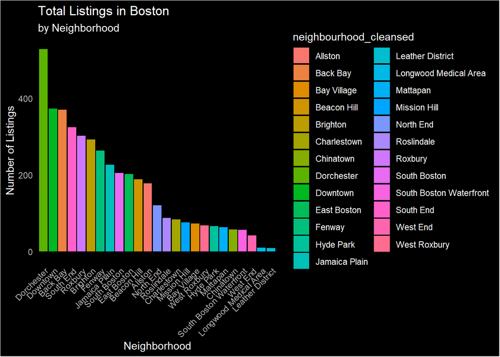

```r
Boston_Listings_by_Neighborhood
```

```r
ggsave("Boston_Listings_by_Neighborhood.png",
       plot = Boston_Listings_by_Neighborhood,
       width = 10, height = 6, dpi = 300)
```

##Chicago

[figure not shown]

```r
#Finding listing's by neighborhood for each city
Chicago_Sum_by_Neighborhood = all_chicago%>%
  group_by(neighbourhood_cleansed)%>%
  summarize(Total_Listings = n_distinct(listing_id), .groups = "drop")

#Chicago
Chicago_Listings_by_Neighborhood = ggplot(Chicago_Sum_by_Neighborhood,
                                 mapping = aes(x = reorder(neighbourhood_cleansed,                                          -Total_Listings),
                                 y = Total_Listings,
                                 fill = neighbourhood_cleansed))+
                                 geom_bar(stat = "identity")+
                                 dark_theme_minimal()+
                                 labs(title = "Total Listings in Chicago",
                                 subtitle = "by Neighborhood",
                                 x = "Neighborhood",
                                 y = "Number of Listings")+
                                 theme(panel.grid.major = element_blank(),
                                 panel.grid.minor = element_blank(),
                                 panel.background = element_blank(),
                                 axis.text.x = element_text(angle = 45, hjust = 1))


Chicago_Listings_by_Neighborhood
```

```r
ggsave("Chicago_Listings_by_Neighborhood.png",
       plot = Chicago_Listings_by_Neighborhood,
       width = 10, height = 6, dpi = 300)
```

##Denver

[figure not shown]

```r
#Finding listing's by neighborhood for each city
Denver_Sum_by_Neighborhood = all_denver%>%
  group_by(neighbourhood_cleansed)%>%
  summarize(Total_Listings = n_distinct(listing_id), .groups = "drop")

#Denver
Denver_Listings_by_Neighborhood = ggplot(Denver_Sum_by_Neighborhood,
                                 mapping = aes(x = reorder(neighbourhood_cleansed,                                          -Total_Listings),
                                 y = Total_Listings,
                                 fill = neighbourhood_cleansed))+
                                 geom_bar(stat = "identity")+
                                 dark_theme_minimal()+
                                 labs(title = "Total Listings in Denver",
                                 subtitle = "by Neighborhood",
                                 x = "Neighborhood",
                                 y = "Number of Listings")+
                                 theme(panel.grid.major = element_blank(),
                                 panel.grid.minor = element_blank(),
                                 panel.background = element_blank(),
                                 axis.text.x = element_text(angle = 45, hjust = 1))


Denver_Listings_by_Neighborhood
```

```r
ggsave("Denver_Listings_by_Neighborhood.png",
       plot = Denver_Listings_by_Neighborhood,
       width = 10, height = 6, dpi = 300)
```

##San Francisco

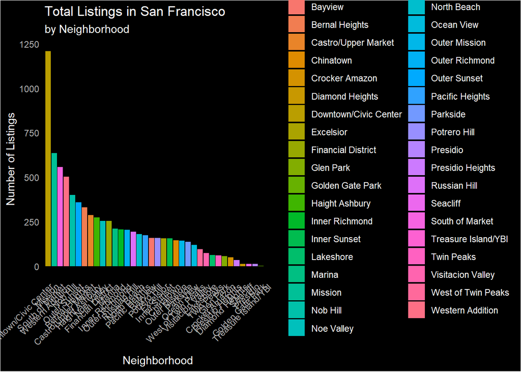

```r
#Finding listing's by neighborhood for each city
SF_Sum_by_Neighborhood = all_sf%>%
  group_by(neighbourhood_cleansed)%>%
  summarize(Total_Listings = n_distinct(listing_id), .groups = "drop")

#SF
SF_Listings_by_Neighborhood = ggplot(SF_Sum_by_Neighborhood,
                                 mapping = aes(x = reorder(neighbourhood_cleansed,                                          -Total_Listings),
                                 y = Total_Listings,
                                 fill = neighbourhood_cleansed))+
                                 geom_bar(stat = "identity")+
                                 dark_theme_minimal()+
                                 labs(title = "Total Listings in San Francisco",
                                 subtitle = "by Neighborhood",
                                 x = "Neighborhood",
                                 y = "Number of Listings")+
                                 theme(panel.grid.major = element_blank(),
                                 panel.grid.minor = element_blank(),
                                 panel.background = element_blank(),
                                 axis.text.x = element_text(angle = 45, hjust = 1))


SF_Listings_by_Neighborhood
```

```r
ggsave("SF_by_Neighborhood.png",
       plot = SF_Listings_by_Neighborhood,
       width = 10, height = 6, dpi = 300)
```

##New York

[figure not shown]

```r
#Finding listing's by neighborhood for each city
NY_Sum_by_Neighborhood = all_ny%>%
  group_by(neighbourhood_cleansed)%>%
  summarize(Total_Listings = n_distinct(listing_id), .groups = "drop")

#NY
NY_Listings_by_Neighborhood = ggplot(NY_Sum_by_Neighborhood,
                                 mapping = aes(x = reorder(neighbourhood_cleansed,                                          -Total_Listings),
                                 y = Total_Listings,
                                 fill = neighbourhood_cleansed))+
                                 geom_bar(stat = "identity")+
                                 dark_theme_minimal()+
                                 labs(title = "Total Listings in New York",
                                 subtitle = "by Neighborhood",
                                 x = "Neighborhood",
                                 y = "Number of Listings")+
                                 theme(panel.grid.major = element_blank(),
                                 panel.grid.minor = element_blank(),
                                 panel.background = element_blank(),
                                 axis.text.x = element_text(angle = 45, hjust = 1))


NY_Listings_by_Neighborhood
```

```r
ggsave("NY_by_Neighborhood.png",
       plot = NY_Listings_by_Neighborhood,
       width = 20, height = 10, dpi = 300)
```

##Time Series of Average Price for Cities Boston

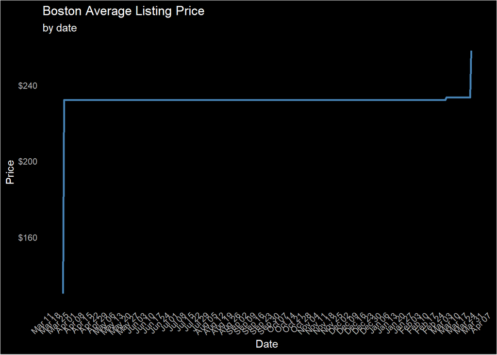

```r
#Force Date in Boston to be a date not posit format
all_boston$date = as.Date(all_boston$date)
#Group by date and find the mean price
Average_Price_Time_Series_Boston = all_boston%>%
  mutate(date = as.Date(date))%>%
  group_by(date)%>%
  summarize(Average_Price = mean(price))

#Average_Price_Time_Series_Boston = Average_Price_Time_Series_Boston%>%
 # mutate(date = as.Date(date))

Average_Price_by_Date_Boston = ggplot(Average_Price_Time_Series_Boston,
                               mapping = aes(x = date, y = Average_Price))+
                               geom_line(color = "steelblue", size = 1)+
                               dark_theme_minimal()+
                               labs(title = "Boston Average Listing Price",
                               subtitle = "by date",
                               x = "Date",
                               y = "Price")+
                               scale_x_date(date_labels = "%b %d", date_breaks = "1 week")+
                               scale_y_continuous(labels = scales::dollar_format()) +
                               theme(panel.grid.major = element_blank(),
                               panel.grid.minor = element_blank(),
                               panel.background = element_blank(),
                               axis.text.x = element_text(angle = 45, hjust = 1))
Average_Price_by_Date_Boston
```

```r
ggsave("Boston Pricing over 2024.png",
       plot = Average_Price_by_Date_Boston,
       width = 10, height = 6, dpi = 300)
```

##Average Price by Neighborhood Boston

```r
Average_Price_Neighborhood_Boston = all_boston%>%
  mutate(date = as.Date(date))%>%
  group_by(neighbourhood_cleansed)%>%
  summarize(Average_Price = mean(price))

head(Average_Price_Neighborhood_Boston, 5)
```

```
## # A tibble: 5 × 2
##   neighbourhood_cleansed Average_Price
##   <fct>                          <dbl>
## 1 Allston                         126.
## 2 Back Bay                        382.
## 3 Bay Village                     301.
## 4 Beacon Hill                     181.
## 5 Brighton                        152.
```

##Visualizing Boston pricing by neighborhood

```r
boston_shp = st_read("C:/Machine Learning for Urban Analysis/Boston_Neighborhood_Boundaries_Approximated_by_2020_Census_Tracts.shp")
colnames(boston_shp)
```

```
## [1] "neighborho" "Shape_Leng" "Shape_Area" "shape_wkt"  "geometry"
```

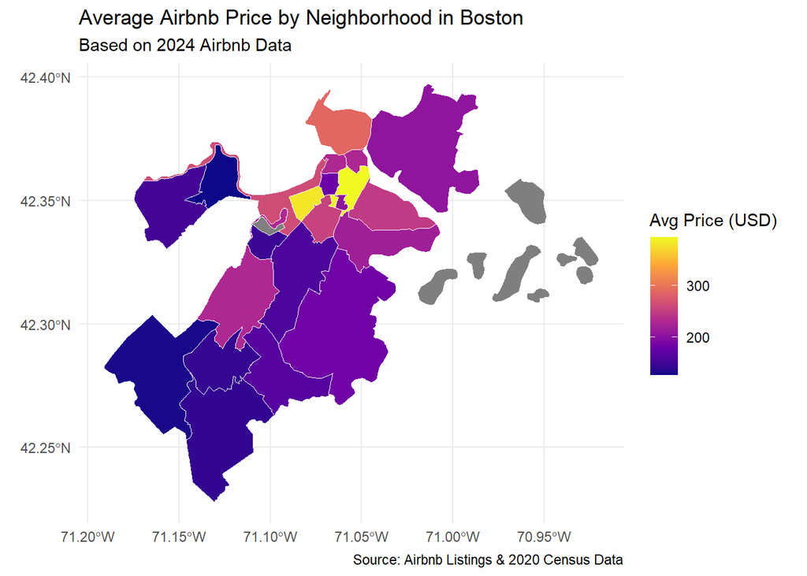

```r
boston_shp = boston_shp %>%
  rename(neighborhood = "neighborho")


Average_Price_Neighborhood_Boston = all_boston %>%
  group_by(neighbourhood_cleansed) %>%
  summarize(Average_Price = mean(price, na.rm = TRUE))


#Need to standardize names across both files
boston_shp$neighborhood = tolower(boston_shp$neighborhood)

Average_Price_Neighborhood_Boston$neighbourhood_cleansed = tolower(Average_Price_Neighborhood_Boston$neighbourhood_cleansed)

boston_map_data = boston_shp %>%
  left_join(Average_Price_Neighborhood_Boston, by = c("neighborhood" = "neighbourhood_cleansed"))


boston_neighborhood_pricing = ggplot(boston_map_data) +
  geom_sf(aes(fill = Average_Price), color = "white") +  # White borders for neighborhoods
  scale_fill_viridis_c(option = "plasma", name = "Avg Price (USD)") +  # Color scheme
  labs(title = "Average Airbnb Price by Neighborhood in Boston",
       subtitle = "Based on 2024 Airbnb Data",
       caption = "Source: Airbnb Listings & 2020 Census Data") +
  theme_minimal()

boston_neighborhood_pricing
```

```r
ggsave("Boston Neighborhood Pricing  2024.png",
       plot = boston_neighborhood_pricing,
       width = 10, height = 6, dpi = 300)
```

##Time Series of Average Price for Chicago

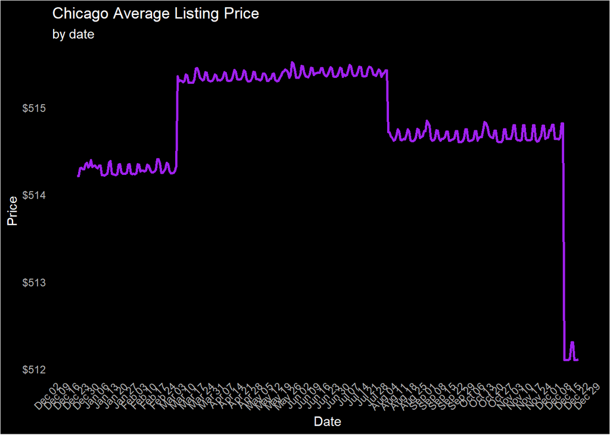

```r
#Force Date in Chicago to be a date not posit format
all_chicago$date = as.Date(all_chicago$date)
#Group by date and find the mean price
Average_Price_Time_Series_Chicago = all_chicago%>%
  mutate(date = as.Date(date))%>%
  group_by(date)%>%
  summarize(Average_Price = mean(price))


Average_Price_by_Date_Chicago= ggplot(Average_Price_Time_Series_Chicago,
                               mapping = aes(x = date, y = Average_Price))+
                               geom_line(color = "purple", size = 1)+
                               dark_theme_minimal()+
                               labs(title = "Chicago Average Listing Price",
                               subtitle = "by date",
                               x = "Date",
                               y = "Price")+
                               scale_x_date(date_labels = "%b %d", date_breaks = "1 week")+
                               scale_y_continuous(labels = scales::dollar_format()) +
                               theme(panel.grid.major = element_blank(),
                               panel.grid.minor = element_blank(),
                               panel.background = element_blank(),
                               axis.text.x = element_text(angle = 45, hjust = 1))

Average_Price_by_Date_Chicago
```

```r
ggsave("Chicago Pricing over 2024.png",
       plot = Average_Price_by_Date_Chicago,
       width = 10, height = 6, dpi = 300)
```

##Average Price by Neighborhood Chicago

```r
Average_Price_Neighborhood_Chicago = all_chicago%>%
  mutate(date = as.Date(date))%>%
  group_by(neighbourhood_cleansed)%>%
  summarize(Average_Price = mean(price))

head(Average_Price_Neighborhood_Chicago, 5)
```

```
## # A tibble: 5 × 2
##   neighbourhood_cleansed Average_Price
##   <fct>                          <dbl>
## 1 Albany Park                     156.
## 2 Archer Heights                  188.
## 3 Armour Square                   382.
## 4 Ashburn                         154.
## 5 Auburn Gresham                  155.
```

```r
chicago_shp = st_read("C:/Machine Learning for Urban Analysis/Chicago_Community_areas.shp")
colnames(chicago_shp)
```

```
##  [1] "FID"        "OBJECTID"   "community"  "area_numbe" "HS_Grad"
##  [6] "BD"         "Unemployed" "Diabetes_r" "Lung_Cance" "Childhood1"
## [11] "Childhood_" "Obesity"    "Firearm_re" "Inequ_inco" "Inactivity"
## [16] "EBLL"       "Shape_Leng" "Shape_Le_1" "Shape_Area" "Shape__Are"
## [21] "Shape__Len" "geometry"
```

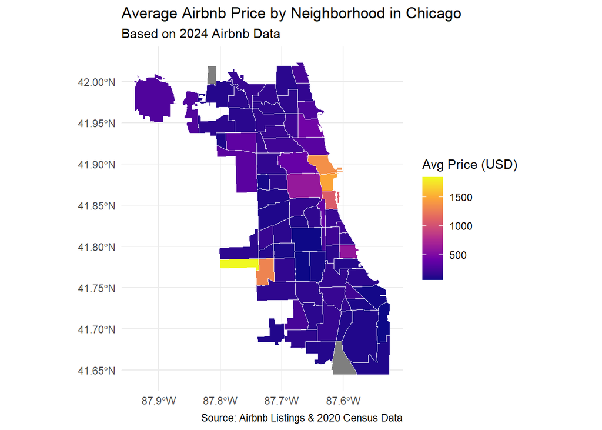

```r
chicago_shp = chicago_shp%>%
  rename(neighborhood = "community")


Average_Price_Neighborhood_Chicago = all_chicago%>%
  group_by(neighbourhood_cleansed) %>%
  summarize(Average_Price = mean(price, na.rm = TRUE))

#Need to standardize names across both files
chicago_shp$neighborhood = tolower(chicago_shp$neighborhood)

Average_Price_Neighborhood_Chicago$neighbourhood_cleansed = tolower(Average_Price_Neighborhood_Chicago$neighbourhood_cleansed)



chicago_map_data = chicago_shp%>%
  left_join(Average_Price_Neighborhood_Chicago, by = c("neighborhood" = "neighbourhood_cleansed"))


chicago_neighborhood_pricing = ggplot(chicago_map_data) +
  geom_sf(aes(fill = Average_Price), color = "white") +
  scale_fill_viridis_c(option = "plasma", name = "Avg Price (USD)") +
  labs(title = "Average Airbnb Price by Neighborhood in Chicago",
       subtitle = "Based on 2024 Airbnb Data",
       caption = "Source: Airbnb Listings & 2020 Census Data") +
  theme_minimal()

chicago_neighborhood_pricing
```

```r
ggsave("Chicago Neighborhood Pricing 2024.png",
       plot = chicago_neighborhood_pricing,
       width = 10, height = 6, dpi = 300)
```

##Time Series of Average Price for Denver

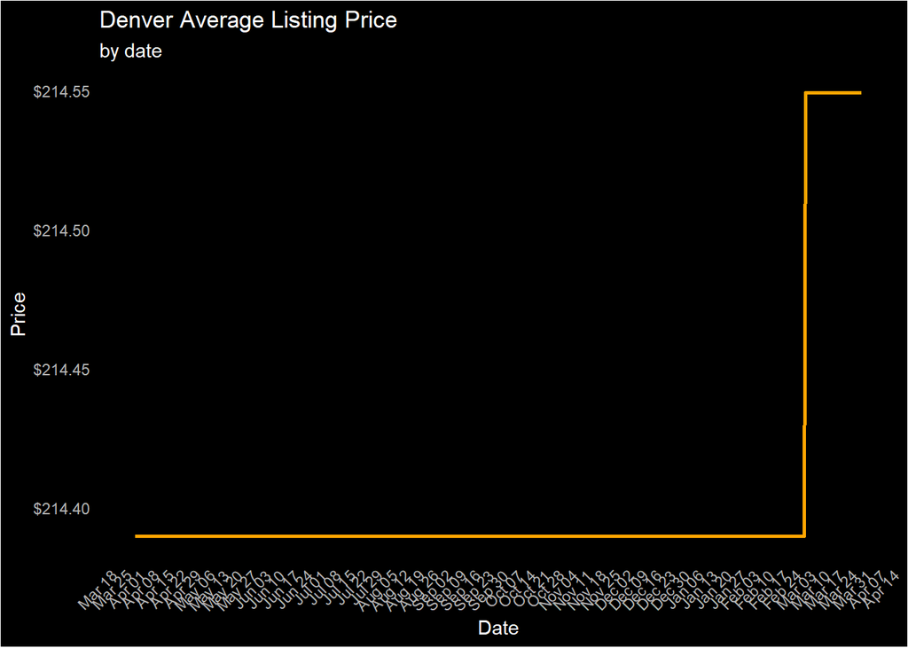

```r
#Force Date in Denver to be a date not posit format
all_denver$date = as.Date(all_denver$date)
#Group by date and find the mean price
Average_Price_Time_Series_Denver = all_denver%>%
  mutate(date = as.Date(date))%>%
  group_by(date)%>%
  summarize(Average_Price = mean(price))


Average_Price_by_Date_Denver= ggplot(Average_Price_Time_Series_Denver,
                               mapping = aes(x = date, y = Average_Price))+
                               geom_line(color = "orange", size = 1)+
                               dark_theme_minimal()+
                               labs(title = "Denver Average Listing Price",
                               subtitle = "by date",
                               x = "Date",
                               y = "Price")+
                               scale_x_date(date_labels = "%b %d", date_breaks = "1 week")+
                               scale_y_continuous(labels = scales::dollar_format()) +
                               theme(panel.grid.major = element_blank(),
                               panel.grid.minor = element_blank(),
                               panel.background = element_blank(),
                               axis.text.x = element_text(angle = 45, hjust = 1))

Average_Price_by_Date_Denver
```

```r
ggsave("Denver Pricing over 2024.png",
       plot = Average_Price_by_Date_Denver,
       width = 10, height = 6, dpi = 300)
```

##Average Price by Neighborhood Denver

```r
Average_Price_Neighborhood_Denver = all_denver%>%
  mutate(date = as.Date(date))%>%
  group_by(neighbourhood_cleansed)%>%
  summarize(Average_Price = mean(price))

head(Average_Price_Neighborhood_Denver, 5)
```

```
## # A tibble: 5 × 2
##   neighbourhood_cleansed Average_Price
##   <fct>                          <dbl>
## 1 Athmar Park                     211.
## 2 Auraria                         135.
## 3 Baker                           158.
## 4 Barnum                          134.
## 5 Barnum West                     131.
```

##Visualizing Denver pricing by neighborhood

```r
denver_shp = st_read("C:/Machine Learning for Urban Analysis/ADMN_NEIGHBORHOOD_A.shp")
colnames(denver_shp)
```

```
## [1] "NBHD_ID"   "NBHD_NAME" "TYPOLOGY"  "NOTES"     "GLOBALID"  "geometry"
```

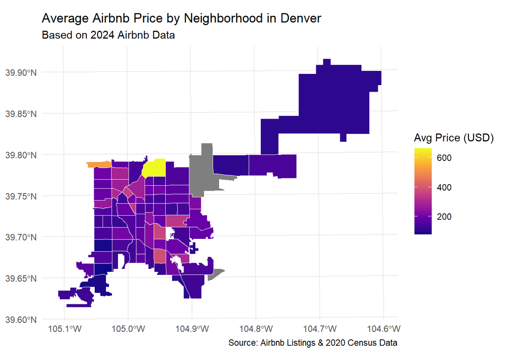

```r
denver_shp = denver_shp%>%
  rename(neighborhood = "NBHD_NAME")


Average_Price_Neighborhood_Denver = all_denver%>%
  group_by(neighbourhood_cleansed) %>%
  summarize(Average_Price = mean(price, na.rm = TRUE))

#Need to standardize names across both files
denver_shp$neighborhood = tolower(denver_shp$neighborhood)

Average_Price_Neighborhood_Denver$neighbourhood_cleansed = tolower(Average_Price_Neighborhood_Denver$neighbourhood_cleansed)

denver_map_data = denver_shp%>%
  left_join(Average_Price_Neighborhood_Denver, by = c("neighborhood" = "neighbourhood_cleansed"))


denver_neighborhood_pricing = ggplot(denver_map_data) +
  geom_sf(aes(fill = Average_Price), color = "white") +  # White borders for neighborhoods
  scale_fill_viridis_c(option = "plasma", name = "Avg Price (USD)") +  # Color scheme
  labs(title = "Average Airbnb Price by Neighborhood in Denver",
       subtitle = "Based on 2024 Airbnb Data",
       caption = "Source: Airbnb Listings & 2020 Census Data") +
  theme_minimal()

denver_neighborhood_pricing
```

```r
ggsave("Denver Neighborhood Pricing  2024.png",
       plot = denver_neighborhood_pricing,
       width = 10, height = 6, dpi = 300)
```

##Time Series of Average Price for New York

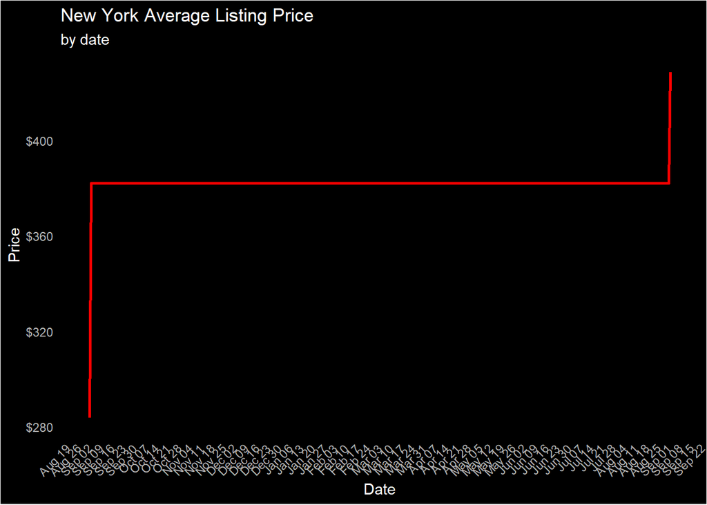

```r
#Force Date in New York to be a date not posit format
all_ny$date = as.Date(all_ny$date)
#Group by date and find the mean price
Average_Price_Time_Series_NY = all_ny%>%
  mutate(date = as.Date(date))%>%
  group_by(date)%>%
  summarize(Average_Price = mean(price))


Average_Price_by_Date_NY= ggplot(Average_Price_Time_Series_NY,
                               mapping = aes(x = date, y = Average_Price))+
                               geom_line(color = "red", size = 1)+
                               dark_theme_minimal()+
                               labs(title = "New York Average Listing Price",
                               subtitle = "by date",
                               x = "Date",
                               y = "Price")+
                               scale_x_date(date_labels = "%b %d", date_breaks = "1 week")+
                               scale_y_continuous(labels = scales::dollar_format()) +
                               theme(panel.grid.major = element_blank(),
                               panel.grid.minor = element_blank(),
                               panel.background = element_blank(),
                               axis.text.x = element_text(angle = 45, hjust = 1))

Average_Price_by_Date_NY
```

```r
ggsave("New York Pricing over 2024.png",
       plot = Average_Price_by_Date_NY,
       width = 10, height = 6, dpi = 300)
```

##Average Price by Neighborhood New York

```r
Average_Price_Neighborhood_NY = all_ny%>%
  mutate(date = as.Date(date))%>%
  group_by(neighbourhood_cleansed)%>%
  summarize(Average_Price = mean(price))

head(Average_Price_Neighborhood_NY, 5)
```

```
## # A tibble: 5 × 2
##   neighbourhood_cleansed Average_Price
##   <fct>                          <dbl>
## 1 Allerton                        121.
## 2 Arden Heights                   126.
## 3 Arrochar                        117.
## 4 Arverne                         244.
## 5 Astoria                         116.
```

##Visualizing New York pricing by neighborhood

```r
ny_shp = st_read("C:/Machine Learning for Urban Analysis/nyct2020.shp")
colnames(ny_shp)
```

```
##  [1] "CTLabel"    "BoroCode"   "BoroName"   "CT2020"     "BoroCT2020"
##  [6] "CDEligibil" "NTAName"    "NTA2020"    "CDTA2020"   "CDTANAME"
## [11] "GEOID"      "PUMA"       "Shape_Leng" "Shape_Area" "geometry"
```

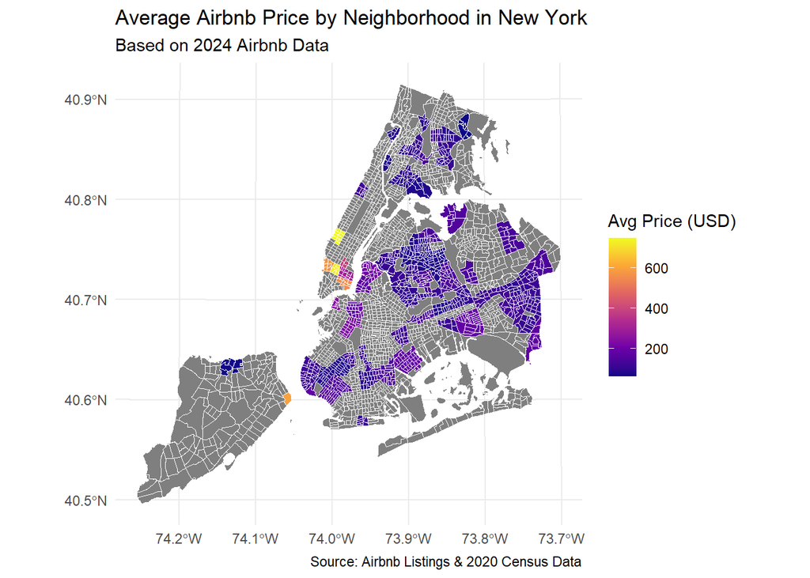

```r
ny_shp = ny_shp%>%
  rename(neighborhood = "NTAName")


Average_Price_Neighborhood_NY = all_ny %>%
  group_by(neighbourhood_cleansed)%>%
  summarize(Average_Price = mean(price, na.rm = TRUE))

#Need to standardize names across both files
ny_shp$neighborhood = tolower(ny_shp$neighborhood)

Average_Price_Neighborhood_NY$neighbourhood_cleansed = tolower(Average_Price_Neighborhood_NY$neighbourhood_cleansed)


ny_map_data = ny_shp%>%
  left_join(Average_Price_Neighborhood_NY, by = c("neighborhood" = "neighbourhood_cleansed"))


ny_neighborhood_pricing = ggplot(ny_map_data) +
  geom_sf(aes(fill = Average_Price), color = "white") +
  scale_fill_viridis_c(option = "plasma", name = "Avg Price (USD)") +
  labs(title = "Average Airbnb Price by Neighborhood in New York",
       subtitle = "Based on 2024 Airbnb Data",
       caption = "Source: Airbnb Listings & 2020 Census Data") +
  theme_minimal()

ny_neighborhood_pricing
```

```r
ggsave("New York Neighborhood Pricing 2024.png",
       plot = ny_neighborhood_pricing,
       width = 10, height = 6, dpi = 300)
```

##Time Series of Average Price for San Francisco

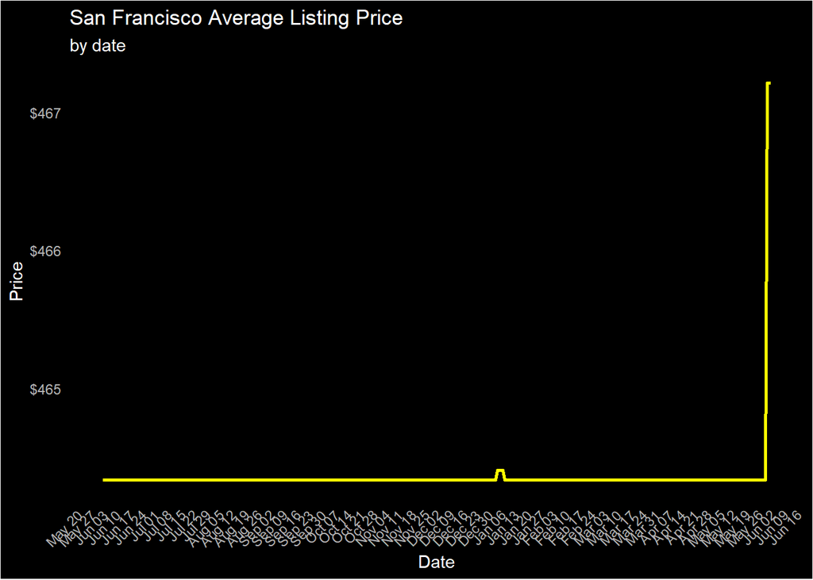

```r
#Force Date in New York to be a date not posit format
all_sf$date = as.Date(all_sf$date)
#Group by date and find the mean price
Average_Price_Time_Series_SF = all_sf%>%
  mutate(date = as.Date(date))%>%
  group_by(date)%>%
  summarize(Average_Price = mean(price))


Average_Price_by_Date_SF= ggplot(Average_Price_Time_Series_SF,
                               mapping = aes(x = date, y = Average_Price))+
                               geom_line(color = "yellow", size = 1)+
                               dark_theme_minimal()+
                               labs(title = "San Francisco Average Listing Price",
                               subtitle = "by date",
                               x = "Date",
                               y = "Price")+
                               scale_x_date(date_labels = "%b %d", date_breaks = "1 week")+
                               scale_y_continuous(labels = scales::dollar_format()) +
                               theme(panel.grid.major = element_blank(),
                               panel.grid.minor = element_blank(),
                               panel.background = element_blank(),
                               axis.text.x = element_text(angle = 45, hjust = 1))

Average_Price_by_Date_SF
```

```r
ggsave("San Francisco Pricing over 2024.png",
       plot = Average_Price_by_Date_SF,
       width = 10, height = 6, dpi = 300)
```

##Average Price by Neighborhood San Francisco

```r
Average_Price_Neighborhood_SF = all_sf%>%
  mutate(date = as.Date(date))%>%
  group_by(neighbourhood_cleansed)%>%
  summarize(Average_Price = mean(price))

head(Average_Price_Neighborhood_SF, 5)
```

```
## # A tibble: 5 × 2
##   neighbourhood_cleansed Average_Price
##   <fct>                          <dbl>
## 1 Bayview                         140.
## 2 Bernal Heights                  266.
## 3 Castro/Upper Market             322.
## 4 Chinatown                       352.
## 5 Crocker Amazon                  108.
```

##Visualizing San Francisco pricing by neighborhood

```r
sf_shp = st_read("C:/Machine Learning for Urban Analysis/geo_export_a12eec05-aade-4fa4-8b8d-62198e99b02c.shp")
colnames(sf_shp)
```

```
## [1] "nhood"    "geometry"
```

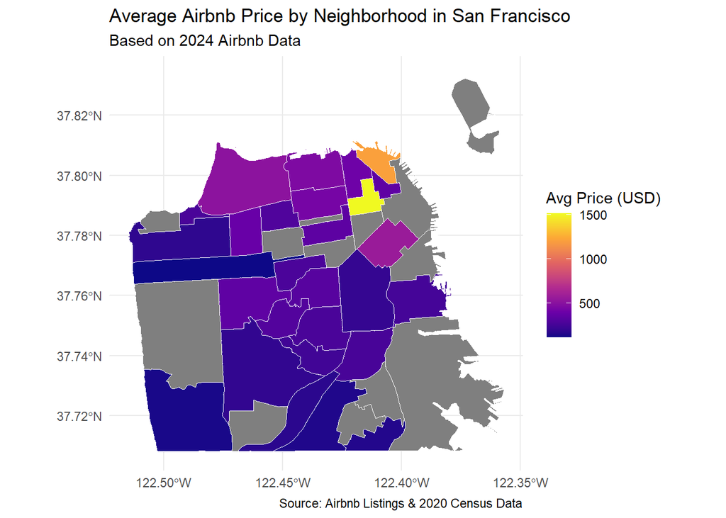

```r
sf_shp = sf_shp%>%
  rename(neighborhood = "nhood")


Average_Price_Neighborhood_SF = all_sf %>%
  group_by(neighbourhood_cleansed)%>%
  summarize(Average_Price = mean(price, na.rm = TRUE))


#Need to standardize names across both files
sf_shp$neighborhood = tolower(sf_shp$neighborhood)

Average_Price_Neighborhood_SF$neighbourhood_cleansed = tolower(Average_Price_Neighborhood_SF$neighbourhood_cleansed)

sf_map_data = sf_shp%>%
  left_join(Average_Price_Neighborhood_SF, by = c("neighborhood" = "neighbourhood_cleansed"))


sf_neighborhood_pricing = ggplot(sf_map_data) +
  geom_sf(aes(fill = Average_Price), color = "white") +
  scale_fill_viridis_c(option = "plasma", name = "Avg Price (USD)") +
  labs(title = "Average Airbnb Price by Neighborhood in San Francisco",
       subtitle = "Based on 2024 Airbnb Data",
       caption = "Source: Airbnb Listings & 2020 Census Data") +
  theme_minimal()

sf_neighborhood_pricing
```

```r
ggsave("San Francisco Neighborhood Pricing 2024.png",
       plot = sf_neighborhood_pricing,
       width = 10, height = 6, dpi = 300)
```

##Trying to group by List ID and look at availibility over time

```r
#Group by date and find the average number of available listings
Average_Total_Listings_Time_Series_Boston = all_boston%>%
  mutate(date = as.Date(date), available = as.numeric(available))%>%
  group_by(date, listing_id)%>%
  summarize(Listings_Available = sum(available) > 0, .groups = "drop")%>%
  group_by(date)%>%
  summarize(Average_Listings_Available = mean(Listings_Available), .groups = "drop")


head(Average_Total_Listings_Time_Series_Boston)
```

```
## # A tibble: 6 × 2
##   date       Average_Listings_Available
##   <date>                          <dbl>
## 1 2024-03-24                      0.209
## 2 2024-03-25                      0.320
## 3 2024-03-26                      0.337
## 4 2024-03-27                      0.347
## 5 2024-03-28                      0.314
## 6 2024-03-29                      0.273
```

##Plotting Boston Listings over Time

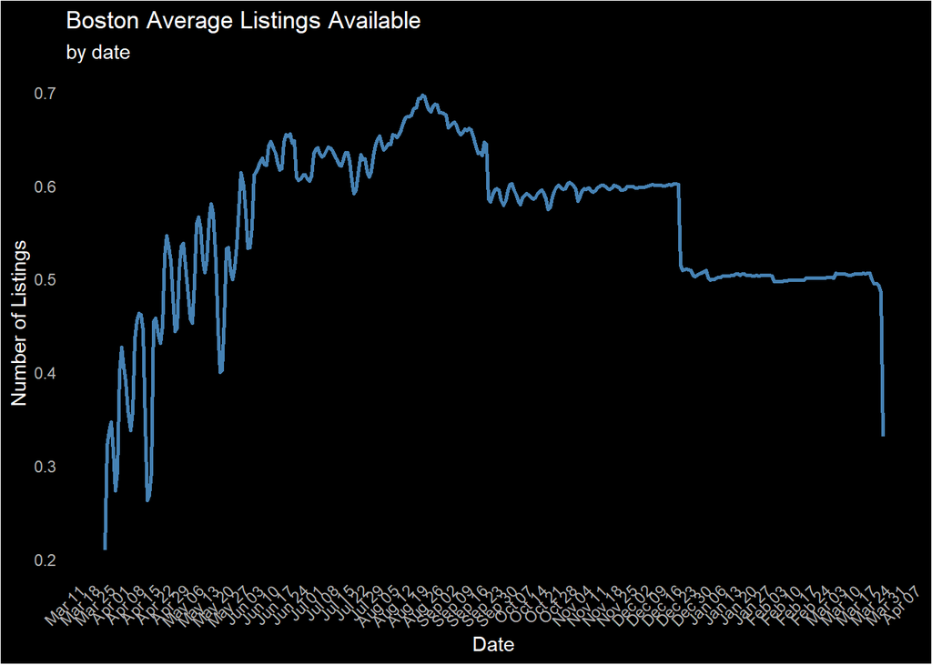

```r
Average_Listings_by_Date_Boston = ggplot(Average_Total_Listings_Time_Series_Boston,
                               mapping = aes(x = date, y = Average_Listings_Available))+
                               geom_line(color = "steelblue", size = 1)+
                               dark_theme_minimal()+
                               labs(title = "Boston Average Listings Available",
                               subtitle = "by date",
                               x = "Date",
                               y = "Number of Listings")+
                               scale_x_date(date_labels = "%b %d", date_breaks = "1 week")+
                               theme(panel.grid.major = element_blank(),
                               panel.grid.minor = element_blank(),
                               panel.background = element_blank(),
                               axis.text.x = element_text(angle = 45, hjust = 1))

Average_Listings_by_Date_Boston
```

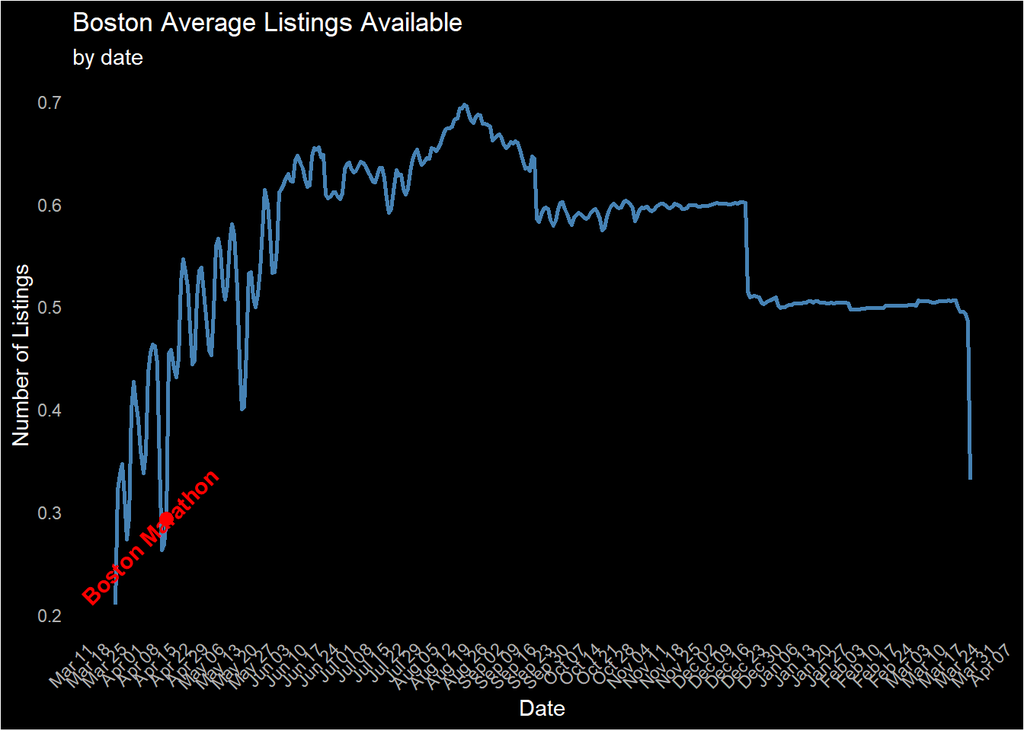

```r
Average_Listings_by_Date_Boston = Average_Listings_by_Date_Boston+
  geom_point(data = Average_Total_Listings_Time_Series_Boston %>% filter(date ==    as.Date("2024-04-15")),aes(x = date, y = Average_Listings_Available),
             color = "red", size = 3)+
  annotate("text", x = as.Date("2024-04-15"), y =    min(Average_Total_Listings_Time_Series_Boston$Average_Listings_Available)+ 0.05,
label = "Boston Marathon", color = "red", fontface = "bold", angle = 45, vjust = -1)


Average_Listings_by_Date_Boston
```

```r
ggsave("Boston Listings over 2024.png",
       plot = Average_Listings_by_Date_Boston,
       width = 10, height = 6, dpi = 300)
```

##Chicago Listings over Time

```r
#Group by date and find the average number of available listings
Average_Total_Listings_Time_Series_Chicago = all_chicago%>%
  mutate(date = as.Date(date), available = as.numeric(available))%>%
  group_by(date, listing_id)%>%
  summarize(Listings_Available = sum(available) > 0, .groups = "drop")%>%
  group_by(date)%>%
  summarize(Average_Listings_Available = mean(Listings_Available), .groups = "drop")


head(Average_Total_Listings_Time_Series_Chicago)
```

```
## # A tibble: 6 × 2
##   date       Average_Listings_Available
##   <date>                          <dbl>
## 1 2024-12-18                      0.438
## 2 2024-12-19                      0.518
## 3 2024-12-20                      0.500
## 4 2024-12-21                      0.483
## 5 2024-12-22                      0.514
## 6 2024-12-23                      0.524
```

##Plotting Chicago Listings over Time

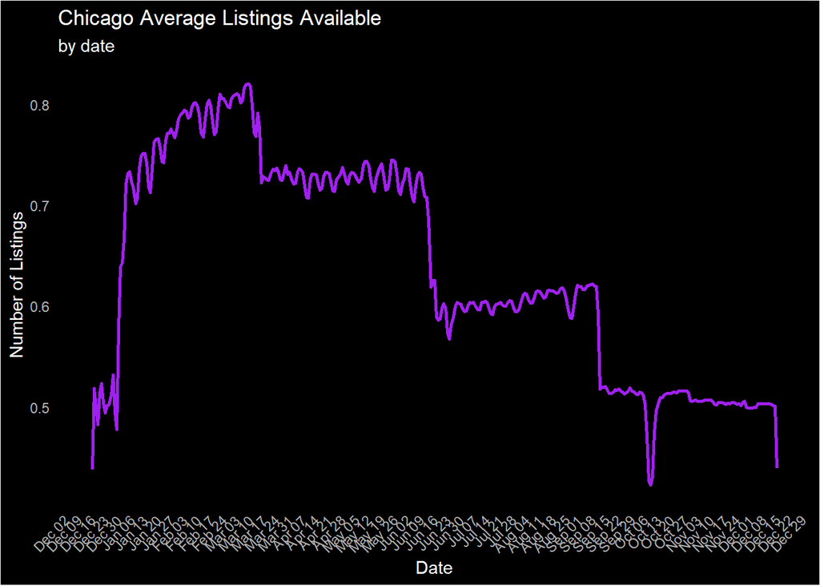

```r
Average_Listings_by_Date_Chicago = ggplot(Average_Total_Listings_Time_Series_Chicago,
                               mapping = aes(x = date, y = Average_Listings_Available))+
                               geom_line(color = "purple", size = 1)+
                               dark_theme_minimal()+
                               labs(title = "Chicago Average Listings Available",
                               subtitle = "by date",
                               x = "Date",
                               y = "Number of Listings")+
                               scale_x_date(date_labels = "%b %d", date_breaks = "1 week")+
                               theme(panel.grid.major = element_blank(),
                               panel.grid.minor = element_blank(),
                               panel.background = element_blank(),
                               axis.text.x = element_text(angle = 45, hjust = 1))

Average_Listings_by_Date_Chicago
```

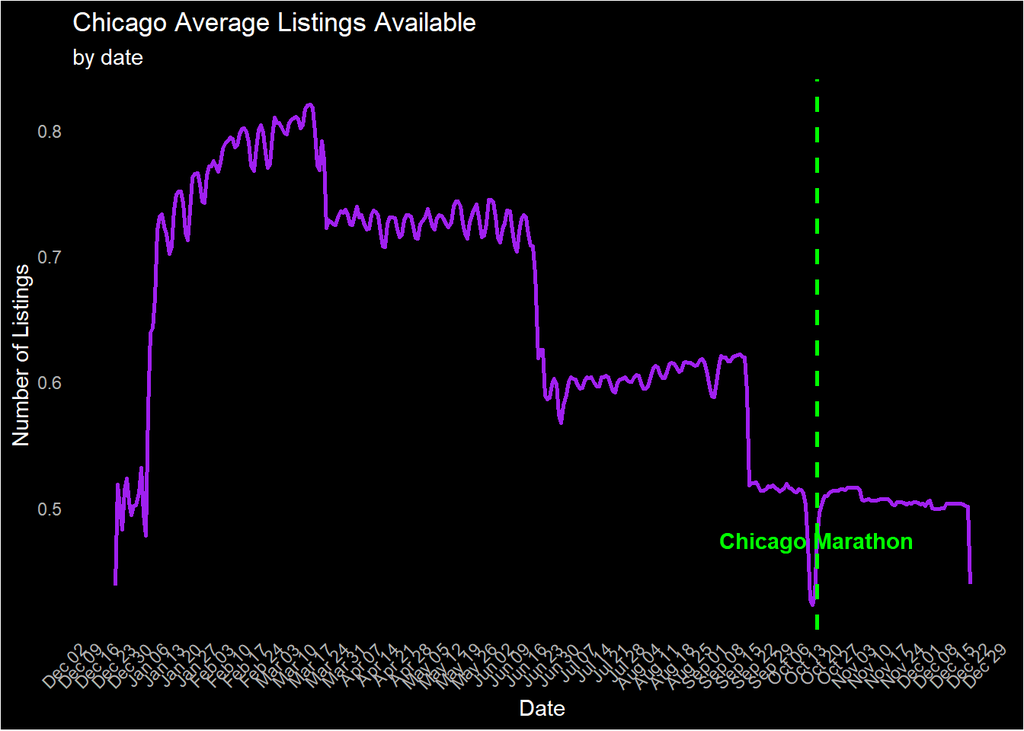

```r
# Find the y-value (dip) for October 13
chicago_marathon_dip = Average_Total_Listings_Time_Series_Chicago%>%
  filter(date == as.Date("2025-10-13"))%>%
  pull(Average_Listings_Available)

# Add dashed line at Oct 13 and correctly position text
Average_Listings_by_Date_Chicago = Average_Listings_by_Date_Chicago+
  geom_vline(xintercept = as.Date("2025-10-13"),
             linetype = "dashed", color = "green", size = 1)+
  annotate("text", x = as.Date("2025-10-13"),
           y = chicago_marathon_dip - 0.02,
           label = "Chicago Marathon",
           color = "green",
           fontface = "bold",
           angle = 0,
           vjust = -1,
           hjust = 0.5)

# Display the updated plot
Average_Listings_by_Date_Chicago
```

```r
ggsave("Chicago Listings over 2024.png",
       plot = Average_Listings_by_Date_Chicago,
       width = 10, height = 6, dpi = 300)
```

##Denver Listings over time

```r
#Group by date and find the average number of available listings
Average_Total_Listings_Time_Series_Denver = all_denver%>%
  mutate(date = as.Date(date), available = as.numeric(available))%>%
  group_by(date, listing_id)%>%
  summarize(Listings_Available = sum(available) > 0, .groups = "drop")%>%
  group_by(date)%>%
  summarize(Average_Listings_Available = mean(Listings_Available), .groups = "drop")


head(Average_Total_Listings_Time_Series_Denver)
```

```
## # A tibble: 6 × 2
##   date       Average_Listings_Available
##   <date>                          <dbl>
## 1 2024-03-31                      0.269
## 2 2024-04-01                      0.380
## 3 2024-04-02                      0.423
## 4 2024-04-03                      0.421
## 5 2024-04-04                      0.364
## 6 2024-04-05                      0.326
```

##Plotting Denver Listings over Time

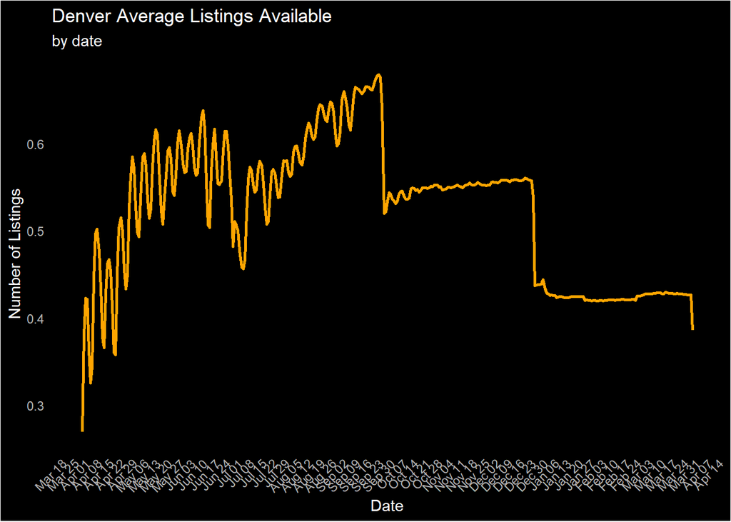

```r
Average_Listings_by_Date_Denver = ggplot(Average_Total_Listings_Time_Series_Denver,
                               mapping = aes(x = date, y = Average_Listings_Available))+
                               geom_line(color = "orange", size = 1)+
                               dark_theme_minimal()+
                               labs(title = "Denver Average Listings Available",
                               subtitle = "by date",
                               x = "Date",
                               y = "Number of Listings")+
                               scale_x_date(date_labels = "%b %d", date_breaks = "1 week")+
                               theme(panel.grid.major = element_blank(),
                               panel.grid.minor = element_blank(),
                               panel.background = element_blank(),
                               axis.text.x = element_text(angle = 45, hjust = 1))

Average_Listings_by_Date_Denver
```

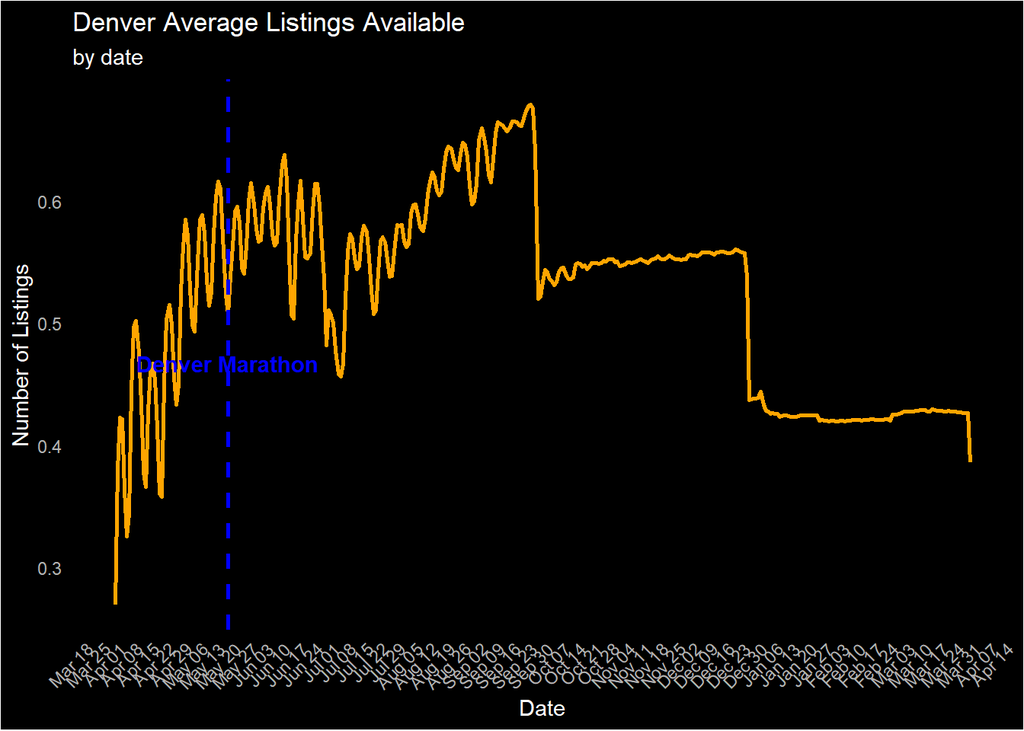

```r
# Find the y-value (dip) for October 13
denver_marathon_dip = Average_Total_Listings_Time_Series_Denver%>%
  filter(date == as.Date("2024-5-18"))%>%
  pull(Average_Listings_Available)

# Add dashed line at Oct 13 and correctly position text
Average_Listings_by_Date_Denver = Average_Listings_by_Date_Denver+
  geom_vline(xintercept = as.Date("2024-5-18"),
             linetype = "dashed", color = "blue", size = 1)+
  annotate("text", x = as.Date("2024-5-18"),
           y = denver_marathon_dip - 0.02,
           label = "Denver Marathon",
           color = "blue",
           fontface = "bold",
           angle = 0,
           vjust = +2,
           hjust = 0.5)

# Display the updated plot
Average_Listings_by_Date_Denver
```

```r
ggsave("Denver Listings over 2024.png",
       plot = Average_Listings_by_Date_Denver,
       width = 10, height = 6, dpi = 300)
```

##New York Listings over time

```r
#Group by date and find the average number of available listings
Average_Total_Listings_Time_Series_NY = all_ny%>%
  mutate(date = as.Date(date), available = as.numeric(available))%>%
  group_by(date, listing_id)%>%
  summarize(Listings_Available = sum(available) > 0, .groups = "drop")%>%
  group_by(date)%>%
  summarize(Average_Listings_Available = mean(Listings_Available), .groups = "drop")


head(Average_Total_Listings_Time_Series_NY)
```

```
## # A tibble: 6 × 2
##   date       Average_Listings_Available
##   <date>                          <dbl>
## 1 2024-09-04                      0.185
## 2 2024-09-05                      0.199
## 3 2024-09-06                      0.229
## 4 2024-09-07                      0.244
## 5 2024-09-08                      0.261
## 6 2024-09-09                      0.260
```

##Plotting New York Listings over Time

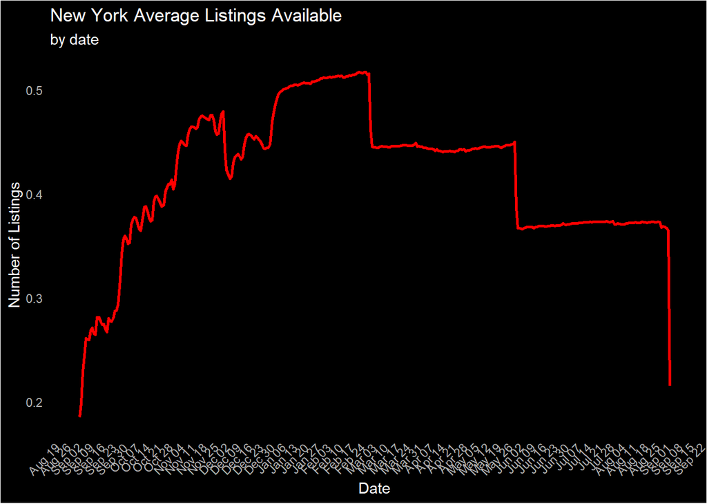

```r
Average_Listings_by_Date_NY = ggplot(Average_Total_Listings_Time_Series_NY,
                               mapping = aes(x = date, y = Average_Listings_Available))+
                               geom_line(color = "red", size = 1)+
                               dark_theme_minimal()+
                               labs(title = "New York Average Listings Available",
                               subtitle = "by date",
                               x = "Date",
                               y = "Number of Listings")+
                               scale_x_date(date_labels = "%b %d", date_breaks = "1 week")+
                               theme(panel.grid.major = element_blank(),
                               panel.grid.minor = element_blank(),
                               panel.background = element_blank(),
                               axis.text.x = element_text(angle = 45, hjust = 1))

Average_Listings_by_Date_NY
```

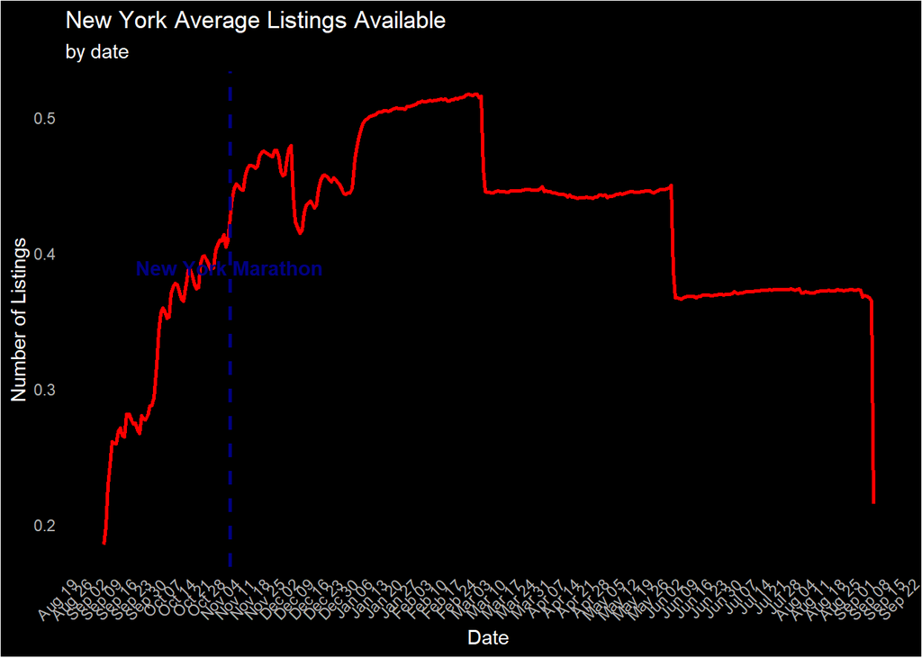

```r
#Dip for NY Marathon
ny_marathon_dip = Average_Total_Listings_Time_Series_NY%>%
  filter(date == as.Date("2024-11-03"))%>%
  pull(Average_Listings_Available)

# Add dashed line at Oct 13 and correctly position text
Average_Listings_by_Date_NY = Average_Listings_by_Date_NY+
  geom_vline(xintercept = as.Date("2024-11-03"),
             linetype = "dashed", color = "navy", size = 1)+
  annotate("text", x = as.Date("2024-11-03"),
           y = ny_marathon_dip - 0.02,
           label = "New York Marathon",
           color = "navy",
           fontface = "bold",
           angle = 0,
           vjust = +2,
           hjust = 0.5)

# Display the updated plot
Average_Listings_by_Date_NY
```

```r
ggsave("New York Listings over 2024.png",
       plot = Average_Listings_by_Date_NY,
       width = 10, height = 6, dpi = 300)
```

##San Francisco Listings over time

```r
#Group by date and find the average number of available listings
Average_Total_Listings_Time_Series_SF = all_sf%>%
  mutate(date = as.Date(date), available = as.numeric(available))%>%
  group_by(date, listing_id)%>%
  summarize(Listings_Available = sum(available) > 0, .groups = "drop")%>%
  group_by(date)%>%
  summarize(Average_Listings_Available = mean(Listings_Available), .groups = "drop")


head(Average_Total_Listings_Time_Series_SF)
```

```
## # A tibble: 6 × 2
##   date       Average_Listings_Available
##   <date>                          <dbl>
## 1 2024-06-04                      0.194
## 2 2024-06-05                      0.273
## 3 2024-06-06                      0.303
## 4 2024-06-07                      0.300
## 5 2024-06-08                      0.289
## 6 2024-06-09                      0.310
```

##Plotting San Francisco Listings over Time

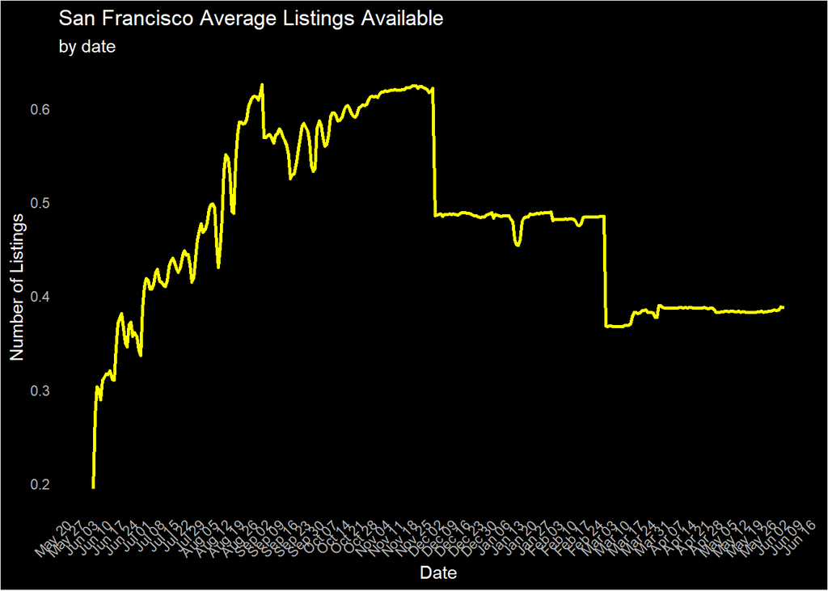

```r
Average_Listings_by_Date_SF = ggplot(Average_Total_Listings_Time_Series_SF,
                               mapping = aes(x = date, y = Average_Listings_Available))+
                               geom_line(color = "yellow", size = 1)+
                               dark_theme_minimal()+
                               labs(title = "San Francisco Average Listings Available",
                               subtitle = "by date",
                               x = "Date",
                               y = "Number of Listings")+
                               scale_x_date(date_labels = "%b %d", date_breaks = "1 week")+
                               theme(panel.grid.major = element_blank(),
                               panel.grid.minor = element_blank(),
                               panel.background = element_blank(),
                               axis.text.x = element_text(angle = 45, hjust = 1))

Average_Listings_by_Date_SF
```

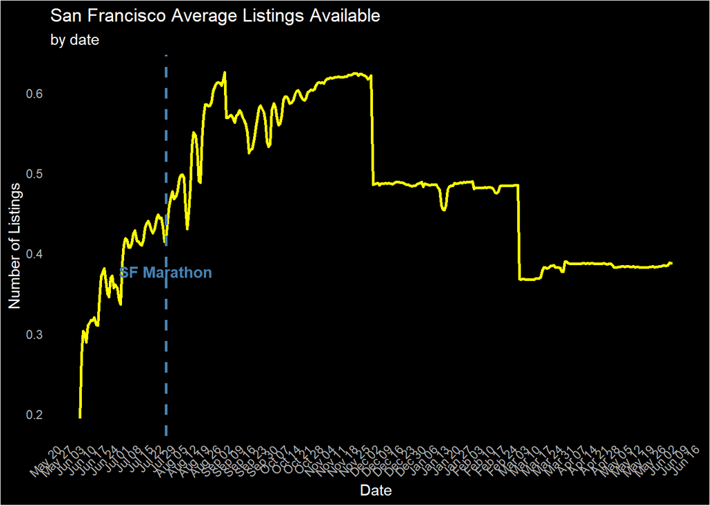

```r
#Find the y-value (dip) for October 13
sf_marathon_dip = Average_Total_Listings_Time_Series_SF%>%
  filter(date == as.Date("2024-7-27"))%>%
  pull(Average_Listings_Available)

#Add dashed line at Oct 13 and correctly position text
Average_Listings_by_Date_SF = Average_Listings_by_Date_SF+
  geom_vline(xintercept = as.Date("2024-7-27"),
             linetype = "dashed", color = "steelblue", size = 1)+
  annotate("text", x = as.Date("2024-7-27"),
           y = sf_marathon_dip - 0.02,
           label = "SF Marathon",
           color = "steelblue",
           fontface = "bold",
           angle = 0,
           vjust = +2,
           hjust = 0.5)

# Display the updated plot
Average_Listings_by_Date_SF
```

```r
ggsave("San Francisco Listings over 2024.png",
       plot = Average_Listings_by_Date_SF,
       width = 10, height = 6, dpi = 300)
```

## Analyzing impact on regional market share Boston

```r
#Boston_Market_Impact_Analysis = all_boston%>%
#  mutate(date = as.Date(date), available = as.numeric(available))%>%
#  group_by(date) %>%
#  summarize(Listings_Available = sum(available > 0), .groups = "drop")

#head(Boston_Market_Impact_Analysis, 5)

#Get the number of unique listings available per day
Boston_Market_Impact_Analysis = all_boston%>%
  mutate(date = as.Date(date), available = as.numeric(available))%>%
  group_by(date, listing_id)%>%
  summarize(Listings_Available = max(available), .groups = "drop")%>%
  group_by(date) %>%
  summarize(Listings_Available = sum(Listings_Available > 0), .groups = "drop")

head(Boston_Market_Impact_Analysis, 5)
```

```
## # A tibble: 5 × 2
##   date       Listings_Available
##   <date>                  <int>
## 1 2024-03-24                169
## 2 2024-03-25               1365
## 3 2024-03-26               1435
## 4 2024-03-27               1478
## 5 2024-03-28               1340
```

##Now find the rolling average number of listings available over the last 2 weeks before the race Boston

```r
#Crate date ranges I want to analyze the number of average available listings 2 weeks before vs the 4 day stretch from 4/12-4/15
boston_before_start = as.Date("2024-03-29")
boston_before_end = as.Date("2024-04-11")
boston_marathon_start = as.Date("2024-04-12")
boston_marathon_end = as.Date("2024-04-15") #14 is sun 15 is mon (day of)

#pre-marathon average
boston_pre_marathon_avg = Boston_Market_Impact_Analysis%>%
  filter(date >= boston_before_start & date <= boston_before_end)%>%
  summarize(Average_Listings_Before = mean(Listings_Available))

#4-day marathon period average
boston_marathon_avg = Boston_Market_Impact_Analysis%>%
  filter(date >= boston_marathon_start & date <= boston_marathon_end)%>%
  summarize(Average_Listings_During = mean(Listings_Available))

#Difference in average availability
boston_market_impact = boston_pre_marathon_avg$Average_Listings_Before - boston_marathon_avg$Average_Listings_During


boston_pre_marathon_avg
```

```
## # A tibble: 1 × 1
##   Average_Listings_Before
##                     <dbl>
## 1                   1675.
```

```r
boston_marathon_avg
```

```
## # A tibble: 1 × 1
##   Average_Listings_During
##                     <dbl>
## 1                   1246.
```

```r
boston_market_impact
```

```
## [1] 428.8571
```

## Analyzing impact on regional market share Chicago

```r
#Get the number of unique listings available per day
Chicago_Market_Impact_Analysis = all_chicago%>%
  mutate(date = as.Date(date), available = as.numeric(available))%>%
  group_by(date, listing_id)%>%
  summarize(Listings_Available = max(available), .groups = "drop")%>%
  group_by(date) %>%
  summarize(Listings_Available = sum(Listings_Available > 0), .groups = "drop")

head(Chicago_Market_Impact_Analysis, 5)
```

```
## # A tibble: 5 × 2
##   date       Listings_Available
##   <date>                  <int>
## 1 2024-12-18               3802
## 2 2024-12-19               4501
## 3 2024-12-20               4342
## 4 2024-12-21               4191
## 5 2024-12-22               4463
```

##Now find the rolling average number of listings available over the last 2 weeks before the race Chicago

```r
#Crate date ranges I want to analyze the number of average available listings 2 weeks before vs the 4 day stretch from 10/11 to 10/14
chicago_before_start = as.Date("2025-09-26")
chicago_before_end = as.Date("2025-10-10")
chicago_marathon_start = as.Date("2025-10-11")
chicago_marathon_end = as.Date("2025-10-13") #13 is sun (day of) 14 is mon

#pre-marathon average
chicago_pre_marathon_avg = Chicago_Market_Impact_Analysis%>%
  filter(date >= chicago_before_start & date <= chicago_before_end)%>%
  summarize(Average_Listings_Before = mean(Listings_Available))

#4-day marathon period average
chicago_marathon_avg = Chicago_Market_Impact_Analysis%>%
  filter(date >= chicago_marathon_start & date <= chicago_marathon_end)%>%
  summarize(Average_Listings_During = mean(Listings_Available))

#Difference in average availability
chicago_market_impact = chicago_pre_marathon_avg$Average_Listings_Before - chicago_marathon_avg$Average_Listings_During


chicago_pre_marathon_avg
```

```
## # A tibble: 1 × 1
##   Average_Listings_Before
##                     <dbl>
## 1                   4387.
```

```r
chicago_marathon_avg
```

```
## # A tibble: 1 × 1
##   Average_Listings_During
##                     <dbl>
## 1                   3843.
```

```r
chicago_market_impact
```

```
## [1] 543.2
```

## Analyzing impact on regional market share Denver

```r
#Get the number of unique listings available per day
Denver_Market_Impact_Analysis = all_denver%>%
  mutate(date = as.Date(date), available = as.numeric(available))%>%
  group_by(date, listing_id)%>%
  summarize(Listings_Available = max(available), .groups = "drop")%>%
  group_by(date) %>%
  summarize(Listings_Available = sum(Listings_Available > 0), .groups = "drop")

head(Denver_Market_Impact_Analysis, 5)
```

```
## # A tibble: 5 × 2
##   date       Listings_Available
##   <date>                  <int>
## 1 2024-03-31               1353
## 2 2024-04-01               1911
## 3 2024-04-02               2124
## 4 2024-04-03               2117
## 5 2024-04-04               1828
```

##Now find the rolling average number of listings available over the last 2 weeks before the race Denver

```r
#Crate date ranges I want to analyze the number of average available listings 2 weeks before vs the 4 day stretch from 10/11 to 10/14
den_before_start = as.Date("2024-05-02")
den_before_end = as.Date("2024-05-16")
den_marathon_start = as.Date("2024-05-17")
den_marathon_end = as.Date("2024-05-19") #19 is sun (day of) 20 is mon

#pre-marathon average
Denver_pre_marathon_avg = Denver_Market_Impact_Analysis%>%
  filter(date >= den_before_start & date <= den_before_end)%>%
  summarize(Average_Listings_Before = mean(Listings_Available))

#4-day marathon period average
Denver_marathon_avg = Denver_Market_Impact_Analysis%>%
  filter(date >= den_marathon_start & date <= den_marathon_end)%>%
  summarize(Average_Listings_During = mean(Listings_Available))

#Difference in average availability
Denver_market_impact = Denver_pre_marathon_avg$Average_Listings_Before - Denver_marathon_avg$Average_Listings_During


Denver_pre_marathon_avg
```

```
## # A tibble: 1 × 1
##   Average_Listings_Before
##                     <dbl>
## 1                   2803.
```

```r
Denver_marathon_avg
```

```
## # A tibble: 1 × 1
##   Average_Listings_During
##                     <dbl>
## 1                   2629.
```

```r
Denver_market_impact
```

```
## [1] 173.6
```

## Analyzing impact on regional market share New York

```r
#Get the number of unique listings available per day
NY_Market_Impact_Analysis = all_ny%>%
  mutate(date = as.Date(date), available = as.numeric(available))%>%
  group_by(date, listing_id)%>%
  summarize(Listings_Available = max(available), .groups = "drop")%>%
  group_by(date) %>%
  summarize(Listings_Available = sum(Listings_Available > 0), .groups = "drop")

head(NY_Market_Impact_Analysis, 5)
```

```
## # A tibble: 5 × 2
##   date       Listings_Available
##   <date>                  <int>
## 1 2024-09-04               2229
## 2 2024-09-05               7457
## 3 2024-09-06               8605
## 4 2024-09-07               9164
## 5 2024-09-08               9808
```

##Now find the rolling average number of listings available over the last 2 weeks before the race New York

```r
#Crate date ranges I want to analyze the number of average available listings 2 weeks before vs the 4 day stretch from 10/11 to 10/14
ny_before_start = as.Date("2024-10-17")
ny_before_end = as.Date("2024-10-31")
ny_marathon_start = as.Date("2024-11-1")
ny_marathon_end = as.Date("2024-11-03") # 3 is sun (day of) 4 is mon

#pre-marathon average
NY_pre_marathon_avg = NY_Market_Impact_Analysis%>%
  filter(date >= ny_before_start & date <= ny_before_end)%>%
  summarize(Average_Listings_Before = mean(Listings_Available))

#4-day marathon period average
NY_marathon_avg = NY_Market_Impact_Analysis%>%
  filter(date >= ny_marathon_start & date <= ny_marathon_end)%>%
  summarize(Average_Listings_During = mean(Listings_Available))

#Difference in average availability
NY_market_impact = NY_pre_marathon_avg$Average_Listings_Before - NY_marathon_avg$Average_Listings_During


NY_pre_marathon_avg
```

```
## # A tibble: 1 × 1
##   Average_Listings_Before
##                     <dbl>
## 1                  14806.
```

```r
NY_marathon_avg
```

```
## # A tibble: 1 × 1
##   Average_Listings_During
##                     <dbl>
## 1                  15518.
```

```r
NY_market_impact
```

```
## [1] -711.3333
```

## Analyzing impact on regional market share San Francisco

```r
#Get the number of unique listings available per day
SF_Market_Impact_Analysis = all_sf%>%
  mutate(date = as.Date(date), available = as.numeric(available))%>%
  group_by(date, listing_id)%>%
  summarize(Listings_Available = max(available), .groups = "drop")%>%
  group_by(date) %>%
  summarize(Listings_Available = sum(Listings_Available > 0), .groups = "drop")

head(SF_Market_Impact_Analysis, 5)
```

```
## # A tibble: 5 × 2
##   date       Listings_Available
##   <date>                  <int>
## 1 2024-06-04               1529
## 2 2024-06-05               2151
## 3 2024-06-06               2391
## 4 2024-06-07               2368
## 5 2024-06-08               2280
```

##Now find the rolling average number of listings available over the last 2 weeks before the race San Francisco

```r
#Crate date ranges I want to analyze the number of average available listings 2 weeks before vs the 4 day stretch from 10/11 to 10/14
sf_before_start = as.Date("2024-07-11")
sf_before_end = as.Date("2024-07-25")
sf_marathon_start = as.Date("2024-07-26")
sf_marathon_end = as.Date("2024-07-28") #28 is sun (day of) 19 is mon

#pre-marathon average
SF_pre_marathon_avg = SF_Market_Impact_Analysis%>%
  filter(date >= sf_before_start & date <= sf_before_end)%>%
  summarize(Average_Listings_Before = mean(Listings_Available))

#4-day marathon period average
SF_marathon_avg = SF_Market_Impact_Analysis%>%
  filter(date >= sf_marathon_start & date <= sf_marathon_end)%>%
  summarize(Average_Listings_During = mean(Listings_Available))

#Difference in average availability
SF_market_impact = SF_pre_marathon_avg$Average_Listings_Before - SF_marathon_avg$Average_Listings_During


SF_pre_marathon_avg
```

```
## # A tibble: 1 × 1
##   Average_Listings_Before
##                     <dbl>
## 1                   3406.
```

```r
SF_marathon_avg
```

```
## # A tibble: 1 × 1
##   Average_Listings_During
##                     <dbl>
## 1                    3349
```

```r
SF_market_impact
```

```
## [1] 57.2
```

##Creating Race Weekend Cols binary numeric in Data Frames

```r
all_boston = all_boston%>%
  mutate(race_weekend = ifelse(date %in% as.Date(c("2024-04-12", "2024-04-13", "2024-04-14","2024-04-15")), 1, 0))

all_chicago = all_chicago%>%
  mutate(race_weekend = ifelse(date %in% as.Date(c("2025-10-11", "2025-10-12", "2025-10-13")), 1, 0))

all_denver = all_denver%>%
  mutate(race_weekend = ifelse(date %in% as.Date(c("2024-05-17", "2024-05-18", "2024-05-19")), 1, 0))

all_ny = all_ny%>%
  mutate(race_weekend = ifelse(date %in% as.Date(c("2024-11-01", "2024-11-02", "2024-11-03")), 1, 0))

all_sf = all_sf%>%
  mutate(race_weekend = ifelse(date %in% as.Date(c("2024-07-26", "2024-07-27", "2024-07-28")), 1, 0))
```

```r
table(all_boston$race_weekend)
```

```
##
##       0       1
## 1537212   17044
```

```r
table(all_chicago$race_weekend)
```

```
##
##       0       1
## 3143277   26055
```

```r
table(all_denver$race_weekend)
```

```
##
##       0       1
## 1818847   15075
```

```r
table(all_ny$race_weekend)
```

```
##
##        0        1
## 13589487   112620
```

```r
table(all_sf$race_weekend)
```

```
##
##       0       1
## 2854905   23661
```

##Seeing if Race weekend has an impact on price for Boston

```r
Boston_Price_Race_Weekend = lm(price ~ race_weekend, data = all_boston)
summary(Boston_Price_Race_Weekend)
```

```
##
## Call:
## lm(formula = price ~ race_weekend, data = all_boston)
##
## Residuals:
##    Min     1Q Median     3Q    Max
## -212.2 -133.2  -73.1   18.8 9767.9
##
## Coefficients:
##              Estimate Std. Error t value Pr(>|t|)
## (Intercept)  232.1912     0.3078  754.30   <2e-16 ***
## race_weekend  -0.0870     2.9395   -0.03    0.976
## ---
## Signif. codes:  0 '***' 0.001 '**' 0.01 '*' 0.05 '.' 0.1 ' ' 1
##
## Residual standard error: 381.7 on 1554254 degrees of freedom
## Multiple R-squared:  5.636e-10,  Adjusted R-squared:  -6.428e-07
## F-statistic: 0.000876 on 1 and 1554254 DF,  p-value: 0.9764
```

##Seeing if Race weekend has an impact on price for Chicago

```r
Chicago_Price_Race_Weekend = lm(price ~ race_weekend, data = all_chicago)
summary(Chicago_Price_Race_Weekend)
```

```
##
## Call:
## lm(formula = price ~ race_weekend, data = all_chicago)
##
## Residuals:
##     Min      1Q  Median      3Q     Max
##  -504.8  -425.8  -367.8  -244.8 17855.2
##
## Coefficients:
##              Estimate Std. Error t value Pr(>|t|)
## (Intercept)  514.8169     1.2212 421.568   <2e-16 ***
## race_weekend  -0.0552    13.4686  -0.004    0.997
## ---
## Signif. codes:  0 '***' 0.001 '**' 0.01 '*' 0.05 '.' 0.1 ' ' 1
##
## Residual standard error: 2165 on 3169330 degrees of freedom
## Multiple R-squared:  5.301e-12,  Adjusted R-squared:  -3.155e-07
## F-statistic: 1.68e-05 on 1 and 3169330 DF,  p-value: 0.9967
```

##Seeing if Race weekend has an impact on price for Denver

```r
Denver_Price_Race_Weekend = lm(price ~ race_weekend, data = all_denver)
summary(Denver_Price_Race_Weekend)
```

```
##
## Call:
## lm(formula = price ~ race_weekend, data = all_denver)
##
## Residuals:
##     Min      1Q  Median      3Q     Max
##  -204.4  -124.4   -84.4    -5.4 11283.6
##
## Coefficients:
##               Estimate Std. Error t value Pr(>|t|)
## (Intercept)  214.40249    0.38393 558.440   <2e-16 ***
## race_weekend  -0.01277    4.23463  -0.003    0.998
## ---
## Signif. codes:  0 '***' 0.001 '**' 0.01 '*' 0.05 '.' 0.1 ' ' 1
##
## Residual standard error: 517.8 on 1833920 degrees of freedom
## Multiple R-squared:  4.956e-12,  Adjusted R-squared:  -5.453e-07
## F-statistic: 9.09e-06 on 1 and 1833920 DF,  p-value: 0.9976
```

##Seeing if Race weekend has an impact on price for New York

```r
NY_Price_Race_Weekend = lm(price ~ race_weekend, data = all_ny)
summary(NY_Price_Race_Weekend)
```

```
##
## Call:
## lm(formula = price ~ race_weekend, data = all_ny)
##
## Residuals:
##    Min     1Q Median     3Q    Max
##   -382   -305   -252   -157  99618
##
## Coefficients:
##               Estimate Std. Error t value Pr(>|t|)
## (Intercept)  3.822e+02  5.191e-01   736.4   <2e-16 ***
## race_weekend 1.415e-04  5.725e+00     0.0        1
## ---
## Signif. codes:  0 '***' 0.001 '**' 0.01 '*' 0.05 '.' 0.1 ' ' 1
##
## Residual standard error: 1913 on 13702105 degrees of freedom
## Multiple R-squared:  4.456e-17,  Adjusted R-squared:  -7.298e-08
## F-statistic: 6.105e-10 on 1 and 13702105 DF,  p-value: 1
```

##Seeing if Race weekend has an impact on price for San Francisco

```r
SF_Price_Race_Weekend = lm(price ~ race_weekend, data = all_sf)
summary(SF_Price_Race_Weekend)
```

```
##
## Call:
## lm(formula = price ~ race_weekend, data = all_sf)
##
## Residuals:
##     Min      1Q  Median      3Q     Max
##  -464.4  -365.4  -304.4  -169.4 24535.7
##
## Coefficients:
##               Estimate Std. Error t value Pr(>|t|)
## (Intercept)  464.36035    1.16286 399.325   <2e-16 ***
## race_weekend  -0.02442   12.82625  -0.002    0.998
## ---
## Signif. codes:  0 '***' 0.001 '**' 0.01 '*' 0.05 '.' 0.1 ' ' 1
##
## Residual standard error: 1965 on 2878564 degrees of freedom
## Multiple R-squared:  1.259e-12,  Adjusted R-squared:  -3.474e-07
## F-statistic: 3.624e-06 on 1 and 2878564 DF,  p-value: 0.9985
```

##Grouping by Neighborhood and Race Weekend

```r
Average_Price_Neighborhood_Boston_Weekend = all_boston%>%
  group_by(neighbourhood_cleansed, race_weekend)%>%
  summarize(Average_Price = mean(price, na.rm = TRUE), .groups = "drop")

Average_Price_Neighborhood_Chicago_Weekend = all_chicago%>%
  group_by(neighbourhood_cleansed, race_weekend)%>%
  summarize(Average_Price = mean(price, na.rm = TRUE), .groups = "drop")

Average_Price_Neighborhood_Denver_Weekend = all_denver%>%
  group_by(neighbourhood_cleansed, race_weekend)%>%
  summarize(Average_Price = mean(price, na.rm = TRUE), .groups = "drop")

Average_Price_Neighborhood_NY_Weekend = all_ny%>%
  group_by(neighbourhood_cleansed, race_weekend)%>%
  summarize(Average_Price = mean(price, na.rm = TRUE), .groups = "drop")

Average_Price_Neighborhood_SF_Weekend = all_sf%>%
  group_by(neighbourhood_cleansed, race_weekend)%>%
  summarize(Average_Price = mean(price, na.rm = TRUE), .groups = "drop")
```

##Seeing if Race Weekend Has an Impact on Average Price by Neighborhood Boston

```r
boston_neighborhood_price_race_weekend = lm(Average_Price ~ race_weekend, data = Average_Price_Neighborhood_Boston_Weekend)

summary(boston_neighborhood_price_race_weekend)
```

```
##
## Call:
## lm(formula = Average_Price ~ race_weekend, data = Average_Price_Neighborhood_Boston_Weekend)
##
## Residuals:
##    Min     1Q Median     3Q    Max
## -91.51 -65.18 -11.77  37.76 177.66
##
## Coefficients:
##              Estimate Std. Error t value Pr(>|t|)
## (Intercept)  217.2782    15.0546  14.433   <2e-16 ***
## race_weekend  -0.1489    21.2904  -0.007    0.994
## ---
## Signif. codes:  0 '***' 0.001 '**' 0.01 '*' 0.05 '.' 0.1 ' ' 1
##
## Residual standard error: 75.27 on 48 degrees of freedom
## Multiple R-squared:  1.019e-06,  Adjusted R-squared:  -0.02083
## F-statistic: 4.892e-05 on 1 and 48 DF,  p-value: 0.9944
```

##Seeing if Race Weekend Has an Impact on Average Price by Neighborhood Chicago

```r
chicago_neighborhood_price_race_weekend = lm(Average_Price ~ race_weekend, data = Average_Price_Neighborhood_Chicago_Weekend)

summary(chicago_neighborhood_price_race_weekend)
```

```
##
## Call:
## lm(formula = Average_Price ~ race_weekend, data = Average_Price_Neighborhood_Chicago_Weekend)
##
## Residuals:
##     Min      1Q  Median      3Q     Max
## -203.79 -146.24 -107.94  -39.95 1577.40
##
## Coefficients:
##               Estimate Std. Error t value Pr(>|t|)
## (Intercept)  269.36692   38.38401   7.018 7.54e-11 ***
## race_weekend  -0.01468   54.28319   0.000        1
## ---
## Signif. codes:  0 '***' 0.001 '**' 0.01 '*' 0.05 '.' 0.1 ' ' 1
##
## Residual standard error: 332.4 on 148 degrees of freedom
## Multiple R-squared:  4.944e-10,  Adjusted R-squared:  -0.006757
## F-statistic: 7.318e-08 on 1 and 148 DF,  p-value: 0.9998
```

##Seeing if Race Weekend Has an Impact on Average Price by Neighborhood Denver

```r
denver_neighborhood_price_race_weekend = lm(Average_Price ~ race_weekend, data = Average_Price_Neighborhood_Denver_Weekend)

summary(denver_neighborhood_price_race_weekend)
```

```
##
## Call:
## lm(formula = Average_Price ~ race_weekend, data = Average_Price_Neighborhood_Denver_Weekend)
##
## Residuals:
##     Min      1Q  Median      3Q     Max
## -114.92  -57.33  -23.33   17.09  469.24
##
## Coefficients:
##                Estimate Std. Error t value Pr(>|t|)
## (Intercept)  193.587055  10.776482  17.964   <2e-16 ***
## race_weekend  -0.008646  15.240247  -0.001        1
## ---
## Signif. codes:  0 '***' 0.001 '**' 0.01 '*' 0.05 '.' 0.1 ' ' 1
##
## Residual standard error: 94.56 on 152 degrees of freedom
## Multiple R-squared:  2.117e-09,  Adjusted R-squared:  -0.006579
## F-statistic: 3.218e-07 on 1 and 152 DF,  p-value: 0.9995
```

##Seeing if Race Weekend Has an Impact on Average Price by Neighborhood New York

```r
ny_neighborhood_price_race_weekend = lm(Average_Price ~ race_weekend, data = Average_Price_Neighborhood_NY_Weekend)

summary(ny_neighborhood_price_race_weekend)
```

```
##
## Call:
## lm(formula = Average_Price ~ race_weekend, data = Average_Price_Neighborhood_NY_Weekend)
##
## Residuals:
##     Min      1Q  Median      3Q     Max
## -174.18 -123.69  -92.71  -25.65 1888.07
##
## Coefficients:
##               Estimate Std. Error t value Pr(>|t|)
## (Intercept)  2.312e+02  1.885e+01   12.26   <2e-16 ***
## race_weekend 1.092e-05  2.666e+01    0.00        1
## ---
## Signif. codes:  0 '***' 0.001 '**' 0.01 '*' 0.05 '.' 0.1 ' ' 1
##
## Residual standard error: 282.8 on 448 degrees of freedom
## Multiple R-squared:  3.743e-16,  Adjusted R-squared:  -0.002232
## F-statistic: 1.677e-13 on 1 and 448 DF,  p-value: 1
```

##Seeing if Race Weekend Has an Impact on Average Price by Neighborhood San Francisco

```r
sf_neighborhood_price_race_weekend = lm(Average_Price ~ race_weekend, data = Average_Price_Neighborhood_SF_Weekend)

summary(sf_neighborhood_price_race_weekend)
```

```
##
## Call:
## lm(formula = Average_Price ~ race_weekend, data = Average_Price_Neighborhood_SF_Weekend)
##
## Residuals:
##     Min      1Q  Median      3Q     Max
## -259.42 -190.71  -94.11   20.20 1147.99
##
## Coefficients:
##               Estimate Std. Error t value Pr(>|t|)
## (Intercept)  367.90953   53.17631   6.919 1.56e-09 ***
## race_weekend  -0.02838   75.20266   0.000        1
## ---
## Signif. codes:  0 '***' 0.001 '**' 0.01 '*' 0.05 '.' 0.1 ' ' 1
##
## Residual standard error: 323.5 on 72 degrees of freedom
## Multiple R-squared:  1.978e-09,  Adjusted R-squared:  -0.01389
## F-statistic: 1.424e-07 on 1 and 72 DF,  p-value: 0.9997
```

##Race Weekends and Availability (Adding race weekend into total listings df’s)

```r
#Boston
Average_Total_Listings_Race_Weekend_Boston = all_boston%>%
  mutate(date = as.Date(date),
         available = as.numeric(available),
         race_weekend = ifelse(date %in% c("2024-04-12", "2024-04-13", "2024-04-14", "2024-04-15"), 1, 0))%>%
  group_by(date, race_weekend, listing_id)%>%
  summarize(Listings_Available = sum(available) > 0, .groups = "drop")%>%
  group_by(date, race_weekend)%>%
  summarize(Average_Listings_Available = mean(Listings_Available), .groups = "drop")

#Chicago
Average_Total_Listings_Race_Weekend_Chicago = all_chicago%>%
  mutate(date = as.Date(date),
         available = as.numeric(available),
         race_weekend = ifelse(date %in% c("2025-10-11", "2025-10-12", "2025-10-13"), 1, 0))%>%
  group_by(date, race_weekend, listing_id)%>%
  summarize(Listings_Available = sum(available) > 0, .groups = "drop")%>%
  group_by(date, race_weekend)%>%
  summarize(Average_Listings_Available = mean(Listings_Available), .groups = "drop")

#Denver
Average_Total_Listings_Race_Weekend_Denver = all_denver%>%
  mutate(date = as.Date(date),
         available = as.numeric(available),
         race_weekend = ifelse(date %in% c("2024-05-17", "2024-05-18", "2024-05-19"), 1, 0))%>%
  group_by(date, race_weekend, listing_id)%>%
  summarize(Listings_Available = sum(available) > 0, .groups = "drop")%>%
  group_by(date, race_weekend)%>%
  summarize(Average_Listings_Available = mean(Listings_Available), .groups = "drop")

#New York
Average_Total_Listings_Race_Weekend_NY = all_ny%>%
  mutate(date = as.Date(date),
         available = as.numeric(available),
         race_weekend = ifelse(date %in% c("2024-11-01", "2024-11-02", "2024-11-03"), 1, 0))%>%
  group_by(date, race_weekend, listing_id)%>%
  summarize(Listings_Available = sum(available) > 0, .groups = "drop")%>%
  group_by(date, race_weekend)%>%
  summarize(Average_Listings_Available = mean(Listings_Available), .groups = "drop")

#San Francisco
Average_Total_Listings_Race_Weekend_SF = all_sf%>%
  mutate(date = as.Date(date),
         available = as.numeric(available),
         race_weekend = ifelse(date %in% c("2024-07-26", "2024-07-27", "2024-07-28"), 1, 0))%>%
  group_by(date, race_weekend, listing_id)%>%
  summarize(Listings_Available = sum(available) > 0, .groups = "drop")%>%
  group_by(date, race_weekend)%>%
  summarize(Average_Listings_Available = mean(Listings_Available), .groups = "drop")
```

##Boston Listings and Race Weekends Linear Regression

```r
Boston_listings_race_weekend = lm(Average_Listings_Available ~ race_weekend, data = Average_Total_Listings_Race_Weekend_Boston)

summary(Boston_listings_race_weekend)
```

```
##
## Call:
## lm(formula = Average_Listings_Available ~ race_weekend, data = Average_Total_Listings_Race_Weekend_Boston)
##
## Residuals:
##      Min       1Q   Median       3Q      Max
## -0.35305 -0.05856  0.02838  0.05625  0.13458
##
## Coefficients:
##               Estimate Std. Error t value Pr(>|t|)
## (Intercept)   0.562205   0.004218 133.293  < 2e-16 ***
## race_weekend -0.269668   0.040346  -6.684 8.75e-11 ***
## ---
## Signif. codes:  0 '***' 0.001 '**' 0.01 '*' 0.05 '.' 0.1 ' ' 1
##
## Residual standard error: 0.08025 on 364 degrees of freedom
## Multiple R-squared:  0.1093, Adjusted R-squared:  0.1069
## F-statistic: 44.67 on 1 and 364 DF,  p-value: 8.755e-11
```

##Chicago Listings and Race Weekends Linear Regression

```r
Chicago_listings_race_weekend = lm(Average_Listings_Available ~ race_weekend, data = Average_Total_Listings_Race_Weekend_Chicago)

summary(Chicago_listings_race_weekend)
```

```
##
## Call:
## lm(formula = Average_Listings_Available ~ race_weekend, data = Average_Total_Listings_Race_Weekend_Chicago)
##
## Residuals:
##      Min       1Q   Median       3Q      Max
## -0.21290 -0.12436 -0.02384  0.09176  0.17996
##
## Coefficients:
##               Estimate Std. Error t value Pr(>|t|)
## (Intercept)   0.640651   0.005624 113.911  < 2e-16 ***
## race_weekend -0.198126   0.062036  -3.194  0.00153 **
## ---
## Signif. codes:  0 '***' 0.001 '**' 0.01 '*' 0.05 '.' 0.1 ' ' 1
##
## Residual standard error: 0.107 on 363 degrees of freedom
## Multiple R-squared:  0.02733,    Adjusted R-squared:  0.02465
## F-statistic:  10.2 on 1 and 363 DF,  p-value: 0.001527
```

##Denver Listings and Race Weekends Linear Regression

```r
Denver_listings_race_weekend = lm(Average_Listings_Available ~ race_weekend, data = Average_Total_Listings_Race_Weekend_Denver)

summary(Denver_listings_race_weekend)
```

```
##
## Call:
## lm(formula = Average_Listings_Available ~ race_weekend, data = Average_Total_Listings_Race_Weekend_Denver)
##
## Residuals:
##      Min       1Q   Median       3Q      Max
## -0.25362 -0.09462  0.02638  0.04887  0.15613
##
## Coefficients:
##               Estimate Std. Error t value Pr(>|t|)
## (Intercept)  0.5228733  0.0042321 123.549   <2e-16 ***
## race_weekend 0.0003772  0.0466814   0.008    0.994
## ---
## Signif. codes:  0 '***' 0.001 '**' 0.01 '*' 0.05 '.' 0.1 ' ' 1
##
## Residual standard error: 0.08052 on 363 degrees of freedom
## Multiple R-squared:  1.798e-07,  Adjusted R-squared:  -0.002755
## F-statistic: 6.528e-05 on 1 and 363 DF,  p-value: 0.9936
```

##New York Listings and Race Weekends Linear Regression

```r
NY_listings_race_weekend = lm(Average_Listings_Available ~ race_weekend, data = Average_Total_Listings_Race_Weekend_NY)

summary(NY_listings_race_weekend)
```

```
##
## Call:
## lm(formula = Average_Listings_Available ~ race_weekend, data = Average_Total_Listings_Race_Weekend_NY)
##
## Residuals:
##      Min       1Q   Median       3Q      Max
## -0.23301 -0.04616  0.02327  0.03493  0.09872
##
## Coefficients:
##               Estimate Std. Error t value Pr(>|t|)
## (Intercept)   0.418217   0.003442 121.502   <2e-16 ***
## race_weekend -0.004854   0.038019  -0.128    0.898
## ---
## Signif. codes:  0 '***' 0.001 '**' 0.01 '*' 0.05 '.' 0.1 ' ' 1
##
## Residual standard error: 0.06558 on 364 degrees of freedom
## Multiple R-squared:  4.477e-05,  Adjusted R-squared:  -0.002702
## F-statistic: 0.0163 on 1 and 364 DF,  p-value: 0.8985
```

##San Francisco Listings and Race Weekends Linear Regression

```r
SF_listings_race_weekend = lm(Average_Listings_Available ~ race_weekend, data = Average_Total_Listings_Race_Weekend_SF)

summary(SF_listings_race_weekend)
```

```
##
## Call:
## lm(formula = Average_Listings_Available ~ race_weekend, data = Average_Total_Listings_Race_Weekend_SF)
##
## Residuals:
##       Min        1Q    Median        3Q       Max
## -0.279887 -0.086911  0.009323  0.089708  0.151709
##
## Coefficients:
##               Estimate Std. Error t value Pr(>|t|)
## (Intercept)   0.473751   0.004814  98.404   <2e-16 ***
## race_weekend -0.049128   0.053103  -0.925    0.356
## ---
## Signif. codes:  0 '***' 0.001 '**' 0.01 '*' 0.05 '.' 0.1 ' ' 1
##
## Residual standard error: 0.0916 on 363 degrees of freedom
## Multiple R-squared:  0.002352,   Adjusted R-squared:  -0.0003961
## F-statistic: 0.8559 on 1 and 363 DF,  p-value: 0.3555
```